# (1) 概要

- 既存の変数を組み合わせて新しい変数を作ることで、モデリング作成にどれだけ役立つか検証する。
- ２変数以上の変数を組み合わせることで交互作用が働いていい感じに役立たないかを確認する。

### 新変数作成方法

- 現状の変数を可視化し、２変数を組み合わせた時の生存率を見ることで新しい変数を作成する。

### 作成した新変数

> 1. PclassとSex別の生存率から作成
> 2. PclassとAge別の生存率から作成
> 3. PclassとParch別の生存率から作成
> 4. AgeとSex別の生存率から作成
> 5. SibSpとParchとPclass別の生存率から作成
> 6. SexとFare別の生存率から作成

### スコア比較対象

> 1. 既存の変数によるモデル
> 2. 既存の変数+新変数によるモデル
> 3. 1からWrapper Methodで自動選択した変数によるモデル
> 4. 2からWrapper Methodで自動選択した変数によるモデル

### 利用モデル

> - Logistic Regression
> - SVM(rbf kernel)
> - Random Forest
> - Gradient Boosting

### 結果

#### - 各モデルごとの最大スコアと利用変数

| モデル | 特徴量内容 | trainスコア | testスコア | パブリックスコア |
| --- | --- | --- | --- | --- |
| Logistic Regression | 既存変数のみ | 0.82273 | 0.83258 | 0.77990 |
| SVM | ・既存変数のみ ・新規変数追加 | 0.83030 0.82879 | 0.83258 0.81448 | 0.78468 |
| Random Forest | 新規変数追加から特徴量抽出 (３変数自動抽出) | 0.83939 | 0.83258 | 0.78947 |
| Gradient Boosting | 新規変数追加から特徴量抽出 (３変数自動抽出) | 0.84545 | 0.81448 | 0.78468 |

※スコアの有意差を調べていないので、パブリックスコアに差があると言えるかはわからない。

#### ースコア詳細ー

| モデル | 特徴量内容 | trainスコア | testスコア | パブリックスコア |
| --- | --- | --- | --- | --- |
| Logistic Regression | 既存変数のみ | 0.82273 | 0.83258 | **0.77990** |
| Logistic Regression | 新規変数追加 | 0.81515 | 0.83710 | 0.74641 |
| Logistic Regression | 既存変数から特徴量抽出 (７変数自動抽出) | 0.80758 | 0.79638 | 0.74641 |
| Logistic Regression | 新規変数追加から特徴量抽出 (３変数自動抽出) | 0.79394 | 0.80090 | 0.76555 |
| SVM | 既存変数のみ | 0.83030 | 0.83258 | **0.78468** |
| SVM | 新規変数追加 | 0.82879 | 0.81448 | **0.78468** |
| SVM | 既存変数から特徴量抽出 (７変数自動抽出) | 0.83030 | 0.80995 | 0.77511 |
| SVM | 新規変数追加から特徴量抽出 (３変数自動抽出) | 0.82273 | 0.81900 | 0.76076 |
| Random Forest | 既存変数のみ | 0.81061 | 0.84163 | 0.74641 |
| Random Forest | 新規変数追加 | 0.81970 | 0.82805 | 0.74641 |
| Random Forest | 既存変数から特徴量抽出 (７変数自動抽出) | 0.78788 | 0.81900 | 0.77033 |
| Random Forest | 新規変数追加から特徴量抽出 (３変数自動抽出) | 0.83939 | 0.83258 | **0.78947** |
| Gradient Boosting | 既存変数のみ | 0.83940 | 0.83710 | 0.75598 |
| Gradient Boosting | 新規変数追加 | 0.83939 | 0.81900 | 0.74641 |
| Gradient Boosting | 既存変数から特徴量抽出 (７変数自動抽出) | 0.83182 | 0.80995 | 0.77511 |
| Gradient Boosting | 新規変数追加から特徴量抽出 (３変数自動抽出) | 0.84545 | 0.81448 | **0.78468** |

```python
import numpy as np
import pandas as pd

# Normalization
from sklearn.preprocessing import StandardScaler

# Validation
from sklearn.model_selection import GridSearchCV
from sklearn.model_selection import train_test_split
from sklearn.metrics import accuracy_score

# feature selection
from mlxtend.feature_selection import SequentialFeatureSelector as SFS

# Model
from sklearn.linear_model import LogisticRegression
from sklearn.svm import SVC
from sklearn.ensemble import RandomForestClassifier
from sklearn.ensemble import GradientBoostingClassifier

# Visualization
from matplotlib import pyplot as plt
import seaborn as sns
sns.set()
sns.set_style('whitegrid')
```

# (2)前処理

### 以下の順番で前処理実施

1. 変数の確認
2. 各変数の分析
3. 2変数間の分析
4. 3変数間（２つの独立変数と従属変数）の分析
5. 外れ値の処理
6. 欠損値の処理
7. 変数作成
8. 変数変換
9. 特徴量選択  
   上記作業の参考サイト： https://www.analyticsvidhya.com/blog/2016/01/guide-data-exploration/

## 1. 変数の確認

- データ数
- データの内容
- データのタイプ
- 欠損値の有無 などを確認

```python
# データ取り出し
train_df = pd.read_csv('/kaggle/input/titanic/train.csv')
test_df = pd.read_csv('/kaggle/input/titanic/test.csv')

train_df.head()
```

|  | PassengerId | Survived | Pclass | Name | Sex | Age | SibSp | Parch | Ticket | Fare | Cabin | Embarked |
| --- | --- | --- | --- | --- | --- | --- | --- | --- | --- | --- | --- | --- |
| 0 | 1 | 0 | 3 | Braund, Mr. Owen Harris | male | 22.0 | 1 | 0 | A/5 21171 | 7.2500 | NaN | S |
| 1 | 2 | 1 | 1 | Cumings, Mrs. John Bradley (Florence Briggs Th... | female | 38.0 | 1 | 0 | PC 17599 | 71.2833 | C85 | C |
| 2 | 3 | 1 | 3 | Heikkinen, Miss. Laina | female | 26.0 | 0 | 0 | STON/O2. 3101282 | 7.9250 | NaN | S |
| 3 | 4 | 1 | 1 | Futrelle, Mrs. Jacques Heath (Lily May Peel) | female | 35.0 | 1 | 0 | 113803 | 53.1000 | C123 | S |
| 4 | 5 | 0 | 3 | Allen, Mr. William Henry | male | 35.0 | 0 | 0 | 373450 | 8.0500 | NaN | S |

既存の変数がPassengerIDを除き全部利用できるか検証する。

- PassengerId: id
- Survived: 生存フラグ（従属変数）0=死亡、1=生存
- Name: 氏名。Mr. Missなどの敬称有り
- Sex: 性別
- Age: 年齢
- SibSp: 兄弟、配偶者の数
- Parch: 親、子供の数
- Ticket: チケット番号
- Fare: 運賃
- Cabin: 部屋番号か船内区画番号
- Embarked: 乗船した港（C=Cherbourg, Q=Queentown, S=Southampton)

<データタイプ>

> - 文字列型：Name, Sex, Ticket, Cabin, Embarked
> - 数値型：Pclass, Age, SibSp, Parch, Fare

<変数タイプ>

> - categorical変数：Pclass, Sex, SibSp, Parch, Embarked
> - continuous変数：Age, Fare

<他>

> 1. Nameに敬称あるので、敬称でCategori分け検討
> 2. Cabinの利用方法検討
> 3. ticketの利用方法検討

```python
# データ数、欠損値確認
train_df.info()
test_df.info()
```

```
<class 'pandas.core.frame.DataFrame'>
RangeIndex: 891 entries, 0 to 890
Data columns (total 12 columns):
 #   Column       Non-Null Count  Dtype
---  ------       --------------  -----
 0   PassengerId  891 non-null    int64
 1   Survived     891 non-null    int64
 2   Pclass       891 non-null    int64
 3   Name         891 non-null    object
 4   Sex          891 non-null    object
 5   Age          714 non-null    float64
 6   SibSp        891 non-null    int64
 7   Parch        891 non-null    int64
 8   Ticket       891 non-null    object
 9   Fare         891 non-null    float64
 10  Cabin        204 non-null    object
 11  Embarked     889 non-null    object
dtypes: float64(2), int64(5), object(5)
memory usage: 83.7+ KB
<class 'pandas.core.frame.DataFrame'>
RangeIndex: 418 entries, 0 to 417
Data columns (total 11 columns):
 #   Column       Non-Null Count  Dtype
---  ------       --------------  -----
 0   PassengerId  418 non-null    int64
 1   Pclass       418 non-null    int64
 2   Name         418 non-null    object
 3   Sex          418 non-null    object
 4   Age          332 non-null    float64
 5   SibSp        418 non-null    int64
 6   Parch        418 non-null    int64
 7   Ticket       418 non-null    object
 8   Fare         417 non-null    float64
 9   Cabin        91 non-null     object
 10  Embarked     418 non-null    object
dtypes: float64(2), int64(4), object(5)
memory usage: 36.0+ KB
```

欠損値：

- train_data: Age, Cabin, Embarked
- test_data: Age, Fare, Cabin
- Cabinの欠損値が多いが、miceで埋めるか、適当に埋めるかあとで検討

```python
# 前処理用にtrainデータとtestデータ合体
combined_df = pd.concat([train_df, test_df])
combined_df.reset_index(inplace=True, drop=True) # インデックス振り直す
combined_df.info()
```

```
<class 'pandas.core.frame.DataFrame'>
RangeIndex: 1309 entries, 0 to 1308
Data columns (total 12 columns):
 #   Column       Non-Null Count  Dtype
---  ------       --------------  -----
 0   PassengerId  1309 non-null   int64
 1   Survived     891 non-null    float64
 2   Pclass       1309 non-null   int64
 3   Name         1309 non-null   object
 4   Sex          1309 non-null   object
 5   Age          1046 non-null   float64
 6   SibSp        1309 non-null   int64
 7   Parch        1309 non-null   int64
 8   Ticket       1309 non-null   object
 9   Fare         1308 non-null   float64
 10  Cabin        295 non-null    object
 11  Embarked     1307 non-null   object
dtypes: float64(3), int64(4), object(5)
memory usage: 122.8+ KB
```

## (2) 各変数の分析

各独立変数の分布状況を確認する

### ・continuous変数(Age, Fare)の分布状況確認

```
               Age         Fare
count  1046.000000  1308.000000
mean     29.881138    33.295479
std      14.413493    51.758668
min       0.170000     0.000000
25%      21.000000     7.895800
50%      28.000000    14.454200
75%      39.000000    31.275000
max      80.000000   512.329200
```

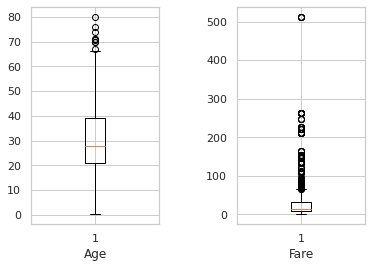

```python
# box plotで可視化

print(combined_df[['Age', 'Fare']].describe())

# 可視化
fig = plt.figure()
plt.subplots_adjust(wspace=0.6)
col = ['Age', 'Fare']
for t in range(len(col)):
    ax = fig.add_subplot(1, 2, t+1)
    ax.boxplot(combined_df[combined_df[col[t]].notnull()][col[t]])
    ax.set_xlabel(col[t])
plt.show()
```

> - 線形回帰モデルも利用するので、Tukey MethodでAge, Fareの外れ値除く

### ・categorical変数(Pclass, Sex, SibSp, Parch, Embarked)の分布状況確認

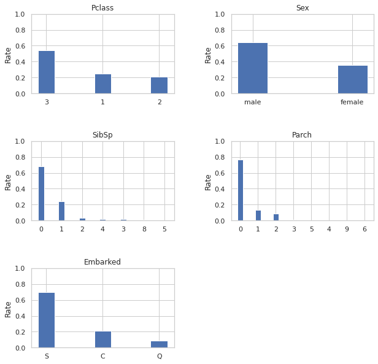

```python
# 棒グラフでカテゴリごとの割合を確認

# 各カテゴリの要素毎の割合算出
count_list = [] # 各categorical変数の割合dfを入れるリスト
cat = ['Pclass', 'Sex', 'SibSp', 'Parch', 'Embarked']
for i in range(len(cat)):
    df = pd.DataFrame(combined_df[cat[i]].value_counts())
    df['ratio'] = df[cat[i]] / df[cat[i]].sum()
    df['ratio'] = df['ratio'].round(2)
    count_list.append(df)

# 可視化
fig = plt.figure(figsize=(10, 10))
plt.subplots_adjust(wspace=0.4, hspace=0.6)
for t in range(len(cat)):
    df = count_list[t]
    ax = fig.add_subplot(3, 2, t+1)
    index = [str(x) for x in df.index] # x軸のインデックス用に文字列化
    ax.bar(index, df['ratio'], width=0.3)
    ax.set_ylim(0, 1)
    ax.set_ylabel('Rate')
    ax.set_title(df.columns[0])
plt.show()
```

> - Pclass: class3が６割、class1と2がそれぞれ２割を占める
> - Sex: 男性が６割、女性が４割
> - SibSp: 兄弟・配偶者が0(一人客)が７割。3人以上は大分少ないので外れ値として外すか？
> - Parch: 親・子供の数が0が８割近い。3人以上は大分少ないので外れ値として外すか？
> - Embarked: Sからの乗船が７割、Cからは２割、Qからは１割
> - SibSpとParchから外れ値除く

### ・Cabinの分布状況確認

```python
combined_df['Cabin'].value_counts()
```

```
C23 C25 C27        6
B57 B59 B63 B66    5
G6                 5
F4                 4
C22 C26            4
                  ..
C103               1
C97                1
D50                1
E58                1
A16                1
Name: Cabin, Length: 186, dtype: int64
```

```python
# Cabinの先頭文字取得、欠損値には'X'で埋め込み
combined_df['Cabin_initial'] = combined_df['Cabin'].apply(lambda x : x[0] if type(x) is str else 'X')

# 後で生存率の確認用にtrain_dfにも用意
train_df['Cabin_initial'] = train_df['Cabin'].apply(lambda x : x[0] if type(x) is str else 'X')

combined_df['Cabin_initial'].value_counts()
```

```
X    1014
C      94
B      65
D      46
E      41
A      22
F      21
G       5
T       1
Name: Cabin_initial, dtype: int64
```

> - ほとんどのデータが欠損値('X')だが、アルファベットごとに生存率に違いがないか後で確認

### ・Nameの状況確認

```python
combined_df['Name'].head(10)
```

```
0                              Braund, Mr. Owen Harris
1    Cumings, Mrs. John Bradley (Florence Briggs Th...
2                               Heikkinen, Miss. Laina
3         Futrelle, Mrs. Jacques Heath (Lily May Peel)
4                             Allen, Mr. William Henry
5                                     Moran, Mr. James
6                              McCarthy, Mr. Timothy J
7                       Palsson, Master. Gosta Leonard
8    Johnson, Mrs. Oscar W (Elisabeth Vilhelmina Berg)
9                  Nasser, Mrs. Nicholas (Adele Achem)
Name: Name, dtype: object
```

> - 敬称で変数化できそうなので、後で敬称ごとの生存率を確認

### ・Ticketの分布状況確認

```python
combined_df['Ticket'].value_counts()
```

```
CA. 2343        11
1601             8
CA 2144          8
S.O.C. 14879     7
PC 17608         7
                ..
347466           1
3101297          1
364511           1
113792           1
A4. 54510        1
Name: Ticket, Length: 929, dtype: int64
```

> - 後で、チケット番号の数値部分を用いて生存者とそれ以外で比較してみる。

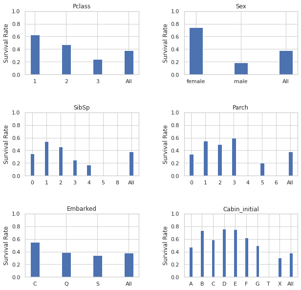

```python
# 各変数ごとの生存状況を可視化

# 生存率計算
cross_list = [] # 各変数ごとのcrosstab集計入れるリスト
cat = ['Pclass', 'Sex', 'SibSp', 'Parch', 'Embarked', 'Cabin_initial']
for i in range(len(cat)):
    cross = pd.crosstab(train_df[cat[i]], train_df['Survived'], margins=True)
    cross['survival_rate'] = cross[1] / cross['All']
    cross['survival_rate'] = cross['survival_rate'].round(2)
    cross_list.append(cross)

# 可視化
fig = plt.figure(figsize=(10, 10))
plt.subplots_adjust(wspace=0.4, hspace=0.6)
for t in range(len(cat)):
    df = cross_list[t]
    ax = fig.add_subplot(3, 2, t+1)
    index = [str(x) for x in df.index]
    ax.bar(index, df['survival_rate'], width=0.3)
    ax.set_ylim(0, 1)
    ax.set_ylabel('Survival Rate')
    ax.set_title(df.index.name)
plt.show()
```

#### 3-1-2 Survivedとcontinuos変数(Age, Fare)の関係

##### ・Survived-Age

年齢をビンわけして、ビンごとの生存率を確認

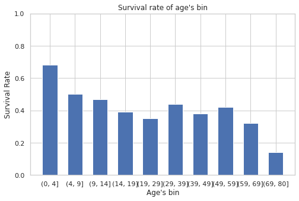

```python
# 子供の生存率が高そうなので、子供のビンを５歳毎、２０歳以上は１０歳ごとにビンわけして、生存率計算
bins = [0, 4, 9, 14, 19, 29, 39, 49, 59, 69, 80]
su_age_df = train_df.loc[:, ['Survived', 'Age']]
su_age_df['bins'] = pd.cut(su_age_df['Age'], bins)
su_age_cross = pd.crosstab(su_age_df['bins'], su_age_df['Survived'])
su_age_cross['All'] = su_age_cross.sum(axis=1)
su_age_cross['survival_rate'] = su_age_cross[1] / su_age_cross['All']
su_age_cross['survival_rate'] = su_age_cross['survival_rate'].round(2)

# 可視化
fig = plt.figure(figsize=(8, 5))
ax = fig.add_subplot(1, 1, 1)
index = [str(x) for x in su_age_cross.index]
ax.bar(index, su_age_cross['survival_rate'], width=0.6)
ax.set_ylim(0, 1)
ax.set_ylabel('Survival Rate')
ax.set_xlabel("Age's bin")
ax.set_title("Survival rate of age's bin")
plt.show()
```

> - 14歳以下の子供の半数は生き残っている。特に４歳以下の生存率は７割

##### ・Survived-Fare

Fareを四分位範囲のビンでわけて、ビンごとに生存率を確認

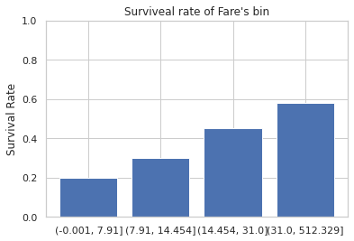

```python
# ビンごとの生存率計算
su_fa_df = train_df.loc[:, ['Survived', 'Fare']]
su_fa_df['bins'] = pd.qcut(su_fa_df['Fare'], 4)
su_fa_cross = pd.crosstab(su_fa_df['bins'], su_fa_df['Survived'])
su_fa_cross['All'] = su_fa_cross.sum(axis=1)
su_fa_cross['survival_rate'] = su_fa_cross[1] / su_fa_cross['All']
su_fa_cross['survival_rate'] = su_fa_cross['survival_rate'].round(2)

# 可視化
fig = plt.figure()
ax = fig.add_subplot(1, 1, 1)
index = [str(x) for x in su_fa_cross.index]
ax.bar(index, su_fa_cross['survival_rate'])
ax.set_ylim(0, 1)
ax.set_ylabel('Survival Rate')
ax.set_title("Surviveal rate of Fare's bin")
plt.show()
```

> - 運賃と生存率に正の相関ありそう

#### 3-1-3 SurvivedとName

Nameから敬称取り出して、敬称毎の生存率を確認

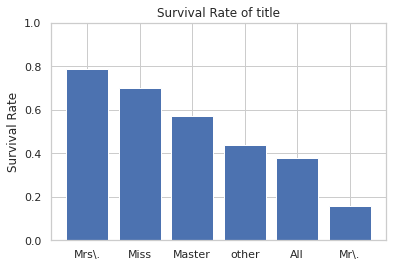

```python
# 敬称取り出し関数の作成
import re
def get_title(name):
    title = ['Mister', 'Mistress', 'Master', 'Mrs\.',
             'Miss', 'Mr\.', 'Prof\.', 'Professor', 'Doctor']
    for ti in title:
        if re.search(ti, name):
            return ti
    # 敬称ヒットしない時はotherを返す
    return 'other'

# 敬称取り出し
na_su_df = train_df.loc[:, ['Survived', 'Name']]
na_su_df['title'] = na_su_df['Name'].apply(get_title)

# 敬称毎の生存率計算
na_su_cross = pd.crosstab(na_su_df['title'], na_su_df['Survived'], margins=True)
na_su_cross['survival_rate'] = na_su_cross[1] / na_su_cross['All']
na_su_cross['survival_rate'] = na_su_cross['survival_rate'].round(2)
na_su_cross = na_su_cross.sort_values(by='survival_rate', ascending=False)

# 可視化
fig = plt.figure()
ax = fig.add_subplot(1, 1, 1)
ax.bar(na_su_cross.index, na_su_cross['survival_rate'])
ax.set_ylim(0, 1)
ax.set_ylabel('Survival Rate')
ax.set_title('Survival Rate of title')
plt.show()

# 敬称補足
# Masterは７歳または１３歳までの男の子につける敬称。
# 参考：https://www.reference.com/world-view/age-master-become-mister-c54996c9aec19c32
```

> - 既婚女性・子連れ女性(Mrs)の生存率は８割
> - 女の子、独身女性(Miss)の生存率が男の子(Master)より１割程度高いので、同じ子供でも性別で生存率に違いありそう
> - 成人男性の生存率は２割未満

#### 3-1-4 SurvivedとTicket

Ticket番号で生存者と死亡者に違いがあるか確認

```python
# Ticket番号の数値部分を取得
ticket_df = train_df[['Survived', 'Ticket']]

# ticket番号の数値部分取得関数
def take_number(ticket_no):

    # ticket番号がLINEの時
    if ticket_no == 'LINE':
        return 0
    # ticket番号が文字と数字の混合の時
    split_nu = ticket_no.split(' ')
    if len(split_nu) > 1:
        return int(re.sub('\\D', '', split_nu[-1]))
    else:
        return int(re.sub('\\D', '', split_nu[0]))

# 番号取得
ticket_df['No'] = train_df['Ticket'].apply(take_number)

ticket_df.head()
```

|  | Survived | Ticket | No |
| --- | --- | --- | --- |
| 0 | 0 | A/5 21171 | 21171 |
| 1 | 1 | PC 17599 | 17599 |
| 2 | 1 | STON/O2. 3101282 | 3101282 |
| 3 | 1 | 113803 | 113803 |
| 4 | 0 | 373450 | 373450 |

```python
ticket_df.groupby('Survived').describe()
```

| Survived | No count | No mean | No std | No min | No 25% | No 50% | No 75% | No max |
| --- | --- | --- | --- | --- | --- | --- | --- | --- |
| 0 | 549.0 | 346495.315118 | 702913.357872 | 0.0 | 14879.00 | 234686.0 | 349221.00 | 3101317.0 |
| 1 | 342.0 | 217518.649123 | 566011.375369 | 0.0 | 14311.25 | 31026.5 | 243871.75 | 3101298.0 |

生存者の中央値値が死亡者より大分小さいのでグラフで見直す

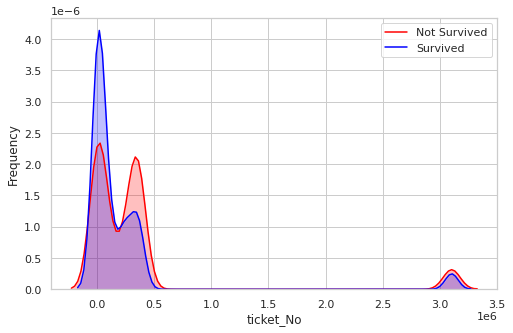

```python
# ヒストグラムでチケット番号ごとの生存状況を確認
plt.figure(figsize=(8, 5))
plot = sns.kdeplot(ticket_df["No"][ticket_df["Survived"] == 0], color="Red", shade = True)
plot = sns.kdeplot(ticket_df["No"][ticket_df["Survived"] == 1], ax = plot, color="Blue", shade= True)
plot.set_xlabel("ticket_No")
plot.set_ylabel("Frequency")
plot = plot.legend(["Not Survived","Survived"])
```

> - チケット番号は25000以下は生存者が多い傾向がありそう。
> - チケット番号を25000前後で分けて変数として利用してみる。

#### 3-1まとめ

> - 「年齢」・「性別」・「運賃」・「子供の有無」で生存率に大きく差がでている。
> - 「年齢」・「性別」・「運賃」・「子供の有無」の各変数をそれぞれ組み合わせてさらに新しい変数を検討する。
> - 「既婚・兄弟(SibSp)」・「子供の有無(Parch)」の数でも生存率に違いがあるので、SibSpとParchを組み合わせた変数も検討する。
> - Cabinもアルファベットで生存率に違いがあったので、変数として使う。
> - Ticketも数字が小さいほうが生存率が高い傾向があったので、変数として使う。

### 3-2 独立変数間の関係チェック

２変数の関係状況と２次元での外れ値の確認

#### 3-2-1 conituous & continuous

AgeとFare の関係

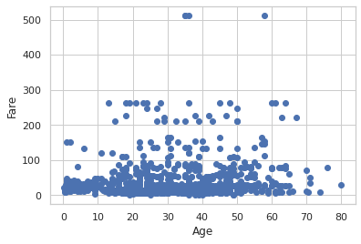

```python
# 散布図作成
plt.figure()
plt.scatter(combined_df['Age'], combined_df['Fare'])
plt.xlabel('Age')
plt.ylabel('Fare')
```

> - 年齢が高いほど高い乗船料というわけではないらしく、２変数に関連はなさそう
> - ５００ドル以上の乗船料は外れ値として外したほうがいい感じ

#### 3-2-2 categorical & categorical

Pclass, Sex, SibSp, Parch, Embarked の各関係

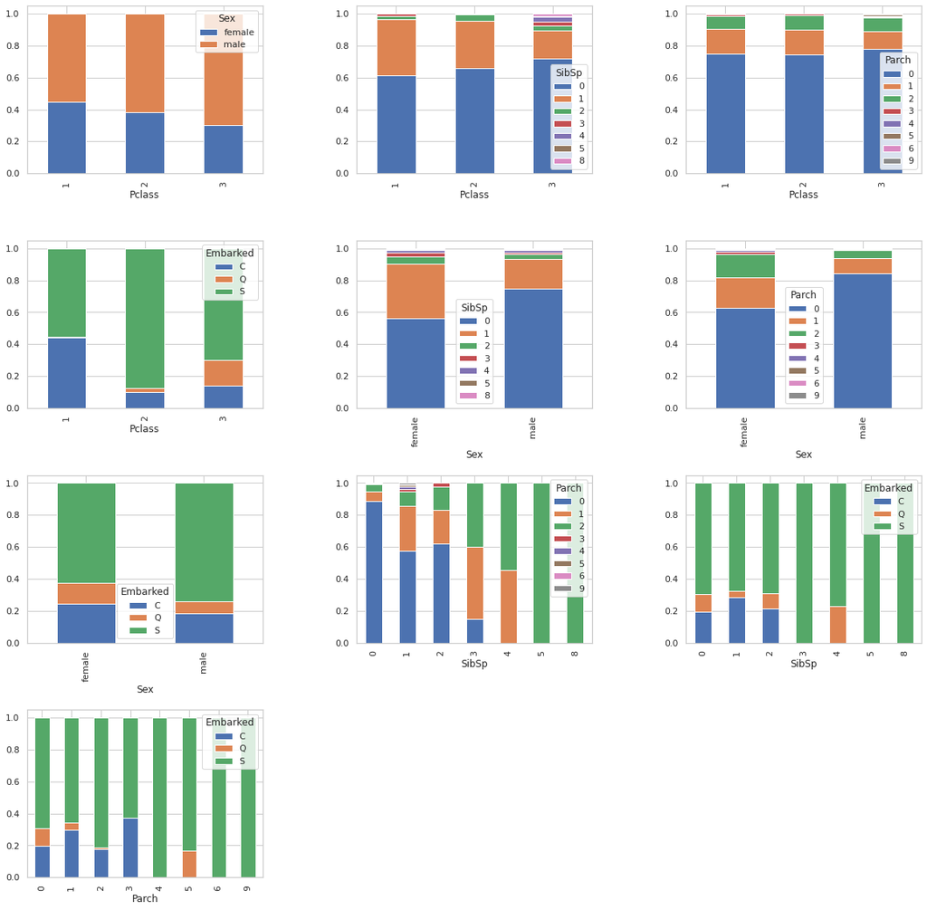

```python
# crosstabで集計して、積み上げ棒グラフで可視化

# 2要素毎にクロス集計
import itertools
cross_list = []
fea_list = ['Pclass', 'Sex', 'SibSp', 'Parch', 'Embarked']
comb_list = list(itertools.combinations(fea_list, 2)) # 変数毎の組み合わせリスト作成
for comb in comb_list:
    cross_list.append(pd.crosstab(combined_df[comb[0]], combined_df[comb[1]], normalize='index')) # 集計結果をindex毎に正規化

# 可視化
fig = plt.figure(figsize=(20,20))
plt.subplots_adjust(wspace=0.4, hspace=0.4)
for t in range(len(cross_list)):
    ax = fig.add_subplot(4, 3, t+1)
    cross_list[t].plot.bar(stacked=True, ax=ax)
plt.show()
```

> - Pclass-Sex: クラスと男女比に大きな違いが無いので、クラス３の女性や子供は生存率が低いかも。
> - Pclass-SibSp, Pclass-Parch: クラス３の家族連れは生存率が低いかも。
> - Sex-SibSp, Sex-Parch: 独り旅は男性が８割占める。ー＞独り旅は、生存率が低そう。

#### 3-2-3 conituous & categorical

Age, Fare と Pclass, Sex, SibSp, Parch, Embarked の各関係

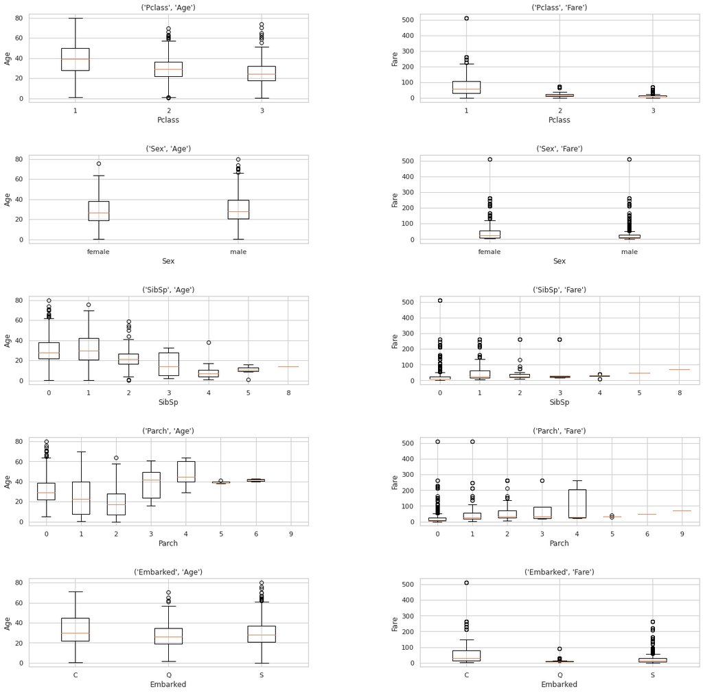

```python
# boxplotで可視化して確認

cat_list = ['Pclass', 'Sex', 'SibSp', 'Parch', 'Embarked'] # categorical変数のリスト
con_list = ['Age', 'Fare'] # numeric変数のリスト

# cat_listとcon_listの要素の直積を求めてグループ化
comb_list = list(itertools.product(cat_list, con_list))
fig = plt.figure(figsize=(20, 20))
plt.subplots_adjust(wspace=0.4, hspace=0.6)
x= 1 # グラフ表示位置用
for comb in comb_list:
    # boxplot用データ作成
    comb_df = combined_df.loc[:, comb]
    comb_dic = comb_df.groupby(comb[0]).indices
    label_list = []
    element_list = []
    for key, index in comb_dic.items():
        label_list.append(key)
        df = comb_df.loc[index, comb[1]]
        element_list.append(list(df[df.notnull()]))
    # 可視化
    ax = fig.add_subplot(5, 2, x)
    ax.boxplot(element_list, labels=label_list)
    ax.set_title(comb)
    ax.set_ylabel(comb[1])
    ax.set_xlabel(comb[0])
    x += 1
plt.show()
```

> - FareとPclassは相関ありそうなので、どっちかあればいいかと思ったが、Pclass2とPclass3の運賃にそんなに差がなさそうなのでどっちも使ってみる。

3.のまとめ

> - それぞれの変数毎に生存率に影響を与えているので、複数の変数の組み合わせによる交互作用で生存率が違ってきそう。
> - なので、２変数を組み合わせた場合のカテゴリごとの生存率を次で調べる。

## 4. 3変数間(2つの独立変数と従属変数)の分析

pclass-Sexごとの生存率といった、２変数間の影響時の生存率を確認する。 また、その結果から新しく変数化できそうなのをピックアップする。

### 変数の組み合わせと仮説

1. Pclass-Sex：クラス３の女性は生存率低そう
2. Pclass-Age：クラス３の子供は生存率低そう
3. Pclass-Parch：クラス３の家族連れは生存率低そう
4. Age-Sex：男の子より女の子の方が生存率高そう
5. SibSP-Parch：一人旅は男性ばかりなので、生存率低そう
6. Fare-Age：運賃安い子供は生存率低そう
7. Sex-Fare：運賃安い女性は生存率低そう

### 4-1 Pclass-Sex別生存率

Pclassが3の女性は生存率が低そうなのでデータから確認

```
Survived         0   1  All  survival_rate
Sex    Pclass
female 1         3  91   94           0.97
       2         6  70   76           0.92
       3        72  72  144           0.50
male   1        77  45  122           0.37
       2        91  17  108           0.16
       3       300  47  347           0.14
```

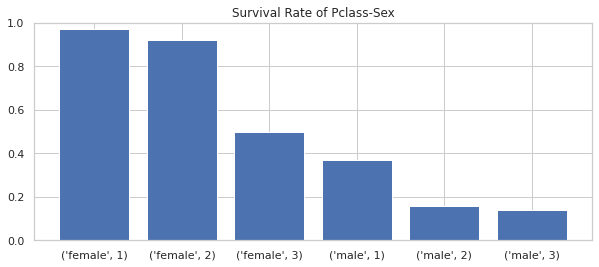

```python
# Pclass-Sexごとの生存率計算
P_S_cross = pd.crosstab([train_df['Sex'],train_df['Pclass']], train_df['Survived'])
P_S_cross['All'] = P_S_cross.sum(axis=1)
P_S_cross['survival_rate'] = P_S_cross[1] / P_S_cross['All']
P_S_cross['survival_rate'] = P_S_cross['survival_rate'].round(2)
print(P_S_cross)

# 可視化
fig =plt.figure(figsize=(10,4))
ax = fig.add_subplot(1,1,1)
index = [str(x) for x in P_S_cross.index]
ax.bar(index, P_S_cross['survival_rate'])
ax.set_ylim(0,1)
ax.set_title('Survival Rate of Pclass-Sex')
plt.show()
```

> - 全ての女性の生存率が高いわけではなく、Pclass1と2の女性の生存率がとても高く、Pclass3の女性の生存率は5割程度。一方で、Pclass1の男性の生存率はPclass2&3の男性の生存率の倍。
> - 「Pclass1&female と Pclass2&female」、「Pclass3&female と Pclass1&male」、「Pclass2&male と Pclass3&male」の３カテゴリで変数化してみる。

### 4-2 Pclass-Age別生存率

クラス３の子供は生存率低そうなので、データで確認

```
Survived           0   1  All  survival_rate
Pclass bins
1      (0, 4]      1   2    3           0.67
       (9, 14]     0   2    2           1.00
       (14, 19]    3  13   16           0.81
       (19, 29]   10  24   34           0.71
       (29, 39]   11  39   50           0.78
       (39, 49]   15  22   37           0.59
       (49, 59]   12  15   27           0.56
       (59, 69]    9   4   13           0.31
       (69, 80]    3   1    4           0.25
2      (0, 4]      0  12   12           1.00
       (4, 9]      0   5    5           1.00
       (9, 14]     0   2    2           1.00
       (14, 19]    9   7   16           0.44
       (19, 29]   31  22   53           0.42
       (29, 39]   29  19   48           0.40
       (39, 49]    8  10   18           0.56
       (49, 59]   10   5   15           0.33
       (59, 69]    2   1    3           0.33
       (69, 80]    1   0    1           0.00
3      (0, 4]     12  13   25           0.52
       (4, 9]     11   6   17           0.35
       (9, 14]     8   3   11           0.27
       (14, 19]   41  14   55           0.25
       (19, 29]  102  31  133           0.23
       (29, 39]   54  15   69           0.22
       (39, 49]   32   2   34           0.06
       (49, 59]    6   0    6           0.00
       (59, 69]    2   1    3           0.33
       (69, 80]    2   0    2           0.00
```

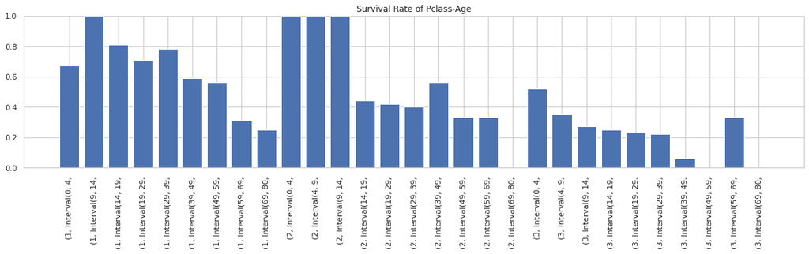

```python
# Pclass-Ageごとの生存率計算
bins = [0, 4, 9, 14, 19, 29, 39, 49, 59, 69, 80]
P_A_df = train_df.loc[:, ['Survived', 'Age', 'Pclass']]
P_A_df['bins'] = pd.cut(P_A_df['Age'], bins)
P_A_cross = pd.crosstab([P_A_df['Pclass'],P_A_df['bins']], P_A_df['Survived'])
P_A_cross['All'] = P_A_cross.sum(axis=1)
P_A_cross['survival_rate'] = P_A_cross[1] / P_A_cross['All']
P_A_cross['survival_rate'] = P_A_cross['survival_rate'].round(2)
print(P_A_cross)

# 可視化
fig =plt.figure(figsize=(20,4))
ax = fig.add_subplot(1,1,1)
index = [str(x).split('closed')[0] for x in P_A_cross.index]
ax.bar(index, P_A_cross['survival_rate'])
ax.set_ylim(0,1)
ax.set_title('Survival Rate of Pclass-Age')
plt.xticks(rotation=90)
plt.show()
```

### 4-3 Pclass-Parch別生存率

Pclass3の家族連れは生存率が低そうなので、データで確認

```
Survived        0   1  All  survival_rate
Pclass Parch
1      0       64  99  163           0.61
       1       10  21   31           0.68
       2        5  16   21           0.76
       4        1   0    1           0.00
2      0       86  48  134           0.36
       1        8  24   32           0.75
       2        3  13   16           0.81
       3        0   2    2           1.00
3      0      295  86  381           0.23
       1       35  20   55           0.36
       2       32  11   43           0.26
       3        2   1    3           0.33
       4        3   0    3           0.00
       5        4   1    5           0.20
       6        1   0    1           0.00
```

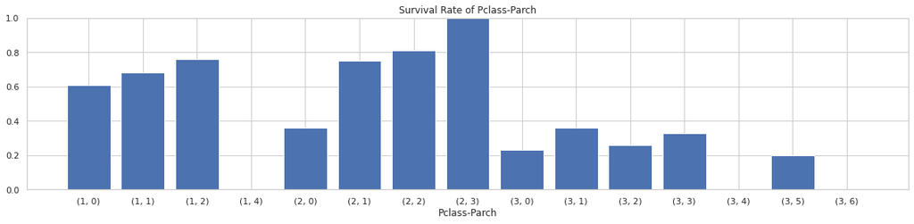

```python
# Pclass-Parchごとの生存率計算
P_P_cross = pd.crosstab([train_df['Pclass'],train_df['Parch']], train_df['Survived'])
P_P_cross['All'] = P_P_cross.sum(axis=1)
P_P_cross['survival_rate'] = P_P_cross[1] / P_P_cross['All']
P_P_cross['survival_rate'] = P_P_cross['survival_rate'].round(2)
print(P_P_cross)

# 可視化
fig =plt.figure(figsize=(20,4))
ax = fig.add_subplot(1,1,1)
index = [str(x) for x in P_P_cross.index]
ax.bar(index, P_P_cross['survival_rate'])
ax.set_ylim(0,1)
ax.set_xlabel('Pclass-Parch')
ax.set_title('Survival Rate of Pclass-Parch')
plt.show()
```

> - Pclass3の家族連れは生存率がPclass1,2の家族連れの半分未満。
> - Pclass1の独り身はPclass2,3の独り身より生存率が高い。ー＞Pclassごとの一人旅の生存率を調べて変数化。
> - 「Pclass1 & Parch0,1,2 と Pclass2 & Parch1,2,3」、「それ以外」のカテゴリで変数化してみる。

### 4-4 Age-Sex別生存率

男の子より女の子の方が生存率が高そう

```
Survived           0   1  All  survival_rate
Sex    bins
female (0, 4]      5  12   17           0.71
       (4, 9]      6   7   13           0.54
       (9, 14]     3   5    8           0.62
       (14, 19]    8  29   37           0.78
       (19, 29]   20  52   72           0.72
       (29, 39]   10  50   60           0.83
       (39, 49]   10  22   32           0.69
       (49, 59]    2  16   18           0.89
       (59, 69]    0   4    4           1.00
male   (0, 4]      8  15   23           0.65
       (4, 9]      5   4    9           0.44
       (9, 14]     5   2    7           0.29
       (14, 19]   45   5   50           0.10
       (19, 29]  123  25  148           0.17
       (29, 39]   84  23  107           0.21
       (39, 49]   45  12   57           0.21
       (49, 59]   26   4   30           0.13
       (59, 69]   13   2   15           0.13
       (69, 80]    6   1    7           0.14
```

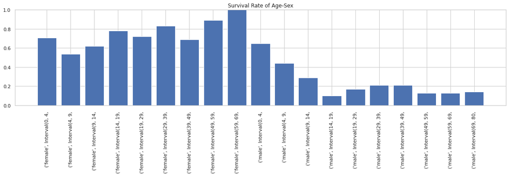

```python
# Age-Sexごとの生存率計算
bins = [0, 4, 9, 14, 19, 29, 39, 49, 59, 69, 80]
A_S_df = train_df.loc[:, ['Survived', 'Age', 'Sex']]
A_S_df['bins'] = pd.cut(A_S_df['Age'], bins)
A_S_cross = pd.crosstab([A_S_df['Sex'],A_S_df['bins']], A_S_df['Survived'])
A_S_cross['All'] = A_S_cross.sum(axis=1)
A_S_cross['survival_rate'] = A_S_cross[1] / A_S_cross['All']
A_S_cross['survival_rate'] = A_S_cross['survival_rate'].round(2)
print(A_S_cross)

# 可視化
fig =plt.figure(figsize=(20,4))
ax = fig.add_subplot(1,1,1)
index = [str(x).split('closed')[0] for x in A_S_cross.index]
ax.bar(index, A_S_cross['survival_rate'])
ax.set_ylim(0,1)
ax.set_title('Survival Rate of Age-Sex')
plt.xticks(rotation=90)
plt.show()
```

### 4-5 SibSp-Parch別生存率

それぞれカテゴリが細かくなるので、SipSp=Parch=0（一人旅）とそれ以外で分けて調べる

```python
# 「一人旅」と「その他」を判別するラベル作成

Si_P_data = train_df[['Survived','SibSp','Parch']]

# SibSpとParchの値からラベルを返す変数
def return_label(df):
    '''
    SibSp = 0 かつ Parch = 0なら0を返す。それ以外は1を返す。
    戻り値0：一人旅、1：その他
    '''
    if df['SibSp'] == 0 and df['Parch'] == 0:
        return 0
    return 1

# 関数適用
Si_P_data['label'] = Si_P_data.apply(return_label, axis=1)
```

```
Survived    0    1  All  survival_rate
label
0         374  163  537           0.30
1         175  179  354           0.51
```

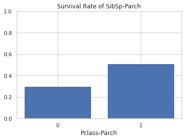

```python
# SibSp-Parchごとの生存率計算
Si_P_cross = pd.crosstab(Si_P_data['label'], Si_P_data['Survived'])
Si_P_cross['All'] = Si_P_cross.sum(axis=1)
Si_P_cross['survival_rate'] = Si_P_cross[1] / Si_P_cross['All']
Si_P_cross['survival_rate'] = Si_P_cross['survival_rate'].round(2)
print(Si_P_cross)

# 可視化
fig =plt.figure()
ax = fig.add_subplot(1,1,1)
index = [str(x) for x in Si_P_cross.index]
ax.bar(index, Si_P_cross['survival_rate'])
ax.set_ylim(0,1)
ax.set_xlabel('Pclass-Parch')
ax.set_title('Survival Rate of SibSp-Parch')
plt.show()
```

> - 一人旅の生存率よりも家族連れの方が生存率が高いが、20％程度の違いしか無い。
> - 「一人旅」と「それ以外」がPclass別でどうなるかついでに調べる。

```
Survived        0   1  All  survival_rate
Pclass label
1      0       51  58  109           0.53
       1       29  78  107           0.73
2      0       68  36  104           0.35
       1       29  51   80           0.64
3      0      255  69  324           0.21
       1      117  50  167           0.30
```

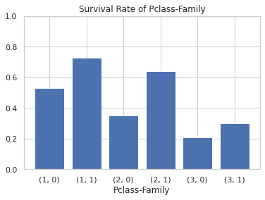

```python
# Pclass-「家族連れ」の生存率確認
# label=0-一人旅、label=1-家族連れ
P_F_df = pd.concat([Si_P_data['label'],train_df[['Survived', 'Pclass']]], axis=1)
P_F_cross = pd.crosstab([P_F_df['Pclass'],P_F_df['label']], P_F_df['Survived'])
P_F_cross['All'] = P_F_cross.sum(axis=1)
P_F_cross['survival_rate'] = P_F_cross[1] / P_F_cross['All']
P_F_cross['survival_rate'] = P_F_cross['survival_rate'].round(2)
print(P_F_cross)

# 可視化
fig =plt.figure()
ax = fig.add_subplot(1,1,1)
index = [str(x) for x in P_F_cross.index]
ax.bar(index, P_F_cross['survival_rate'])
ax.set_ylim(0,1)
ax.set_xlabel('Pclass-Family')
ax.set_title('Survival Rate of Pclass-Family')
plt.show()
```

> - 全ての「一人旅」の生存率が低いわけではなく、Pclass1の「一人旅」は生存率が5割ある。
> - Pclass3の「家族連れ」は、生存率が大分低い。
> - 「Pclass1&家族連れ と Pclass2&家族連れ」、「Pclass1&一人旅」、「その他」でカテゴリ分けして変数化してみる。
> - また、家族連れの女性と男性では生存率に違いがありそうなので、ついでに調べる。

```
Survived        0    1  All  survival_rate
Sex    label
female 0       27   99  126           0.79
       1       54  134  188           0.71
male   0      347   64  411           0.16
       1      121   45  166           0.27
```

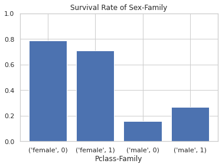

```python
# Sex-「家族連れ(Family)」の生存率確認
# label=0-一人旅、label=1-家族連れ
S_F_df = pd.concat([Si_P_data['label'],train_df[['Survived', 'Sex']]], axis=1)
S_F_cross = pd.crosstab([S_F_df['Sex'],S_F_df['label']], S_F_df['Survived'])
S_F_cross['All'] = S_F_cross.sum(axis=1)
S_F_cross['survival_rate'] = S_F_cross[1] / S_F_cross['All']
S_F_cross['survival_rate'] = S_F_cross['survival_rate'].round(2)
print(S_F_cross)

# 可視化
fig =plt.figure()
ax = fig.add_subplot(1,1,1)
index = [str(x) for x in S_F_cross.index]
ax.bar(index, S_F_cross['survival_rate'])
ax.set_ylim(0,1)
ax.set_xlabel('Pclass-Family')
ax.set_title('Survival Rate of Sex-Family')
plt.show()
```

> - 女性の一人旅の生存率が一番高いが、家族連れでも7割生き残っている。
> - 性別の生存率と結果がそんなに変わらないので、これは変数化しない。

### 4-6 Fare-Age別生存率

運賃安い子供は生存率が低そうなので確認

```
Survived                   0   1  All  survival_rate
Age_bins Fare_bins
(0, 4]   (7.91, 14.454]    1   5    6           0.83
         (14.454, 31.0]    6  15   21           0.71
         (31.0, 512.329]   6   7   13           0.54
(4, 9]   (7.91, 14.454]    0   2    2           1.00
         (14.454, 31.0]    5   6   11           0.55
         (31.0, 512.329]   6   3    9           0.33
(9, 14]  (-0.001, 7.91]    1   1    2           0.50
         (7.91, 14.454]    0   2    2           1.00
         (14.454, 31.0]    3   2    5           0.40
         (31.0, 512.329]   4   2    6           0.33
(14, 19] (-0.001, 7.91]   19   6   25           0.24
         (7.91, 14.454]   18  12   30           0.40
         (14.454, 31.0]    8   5   13           0.38
         (31.0, 512.329]   8  11   19           0.58
(19, 29] (-0.001, 7.91]   51  17   68           0.25
         (7.91, 14.454]   58  16   74           0.22
         (14.454, 31.0]   18  20   38           0.53
         (31.0, 512.329]  16  24   40           0.60
(29, 39] (-0.001, 7.91]   26   1   27           0.04
         (7.91, 14.454]   35  17   52           0.33
         (14.454, 31.0]   23  19   42           0.45
         (31.0, 512.329]  10  36   46           0.78
(39, 49] (-0.001, 7.91]   14   0   14           0.00
         (7.91, 14.454]   11   6   17           0.35
         (14.454, 31.0]   17  11   28           0.39
         (31.0, 512.329]  13  17   30           0.57
(49, 59] (-0.001, 7.91]    3   0    3           0.00
         (7.91, 14.454]   11   2   13           0.15
         (14.454, 31.0]    7   6   13           0.46
         (31.0, 512.329]   7  12   19           0.63
(59, 69] (-0.001, 7.91]    2   0    2           0.00
         (7.91, 14.454]    1   2    3           0.67
         (14.454, 31.0]    5   0    5           0.00
         (31.0, 512.329]   5   4    9           0.44
(69, 80] (-0.001, 7.91]    2   0    2           0.00
         (7.91, 14.454]    1   0    1           0.00
         (14.454, 31.0]    0   1    1           1.00
         (31.0, 512.329]   3   0    3           0.00
```

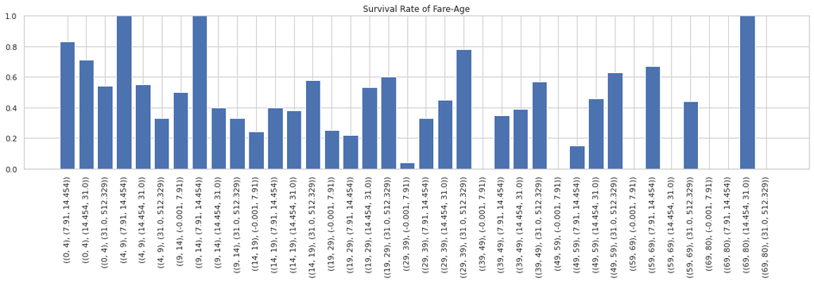

```python
# FareとAgeをビンわけ
# Age-Sexごとの生存率計算
bins = [0, 4, 9, 14, 19, 29, 39, 49, 59, 69, 80] # Ageのビン
F_A_df = train_df.loc[:, ['Survived', 'Age', 'Fare']]
F_A_df['Age_bins'] = pd.cut(F_A_df['Age'], bins)
F_A_df['Fare_bins'] = pd.qcut(F_A_df['Fare'], 4) # Fareは四分位範囲でビンわけ
F_A_cross = pd.crosstab([F_A_df['Age_bins'],F_A_df['Fare_bins']], F_A_df['Survived'])
F_A_cross['All'] = F_A_cross.sum(axis=1)
F_A_cross['survival_rate'] = F_A_cross[1] / F_A_cross['All']
F_A_cross['survival_rate'] = F_A_cross['survival_rate'].round(2)
print(F_A_cross)


# 可視化
fig =plt.figure(figsize=(20,4))
ax = fig.add_subplot(1,1,1)
index = [str(x).replace('Interval','').replace(", closed='right'", "") for x in F_A_cross.index]
ax.bar(index, F_A_cross['survival_rate'])
ax.set_ylim(0,1)
ax.set_title('Survival Rate of Fare-Age')
plt.xticks(rotation=90)
plt.show()
```

### 4-7 Sex-Fare別生存率

運賃安い女性は生存率が低そう、運賃高い男性は比較的生存率が高そう

```
Survived                  0   1  All  survival_rate
Sex    Fare_bins
female (-0.001, 7.91]    13  30   43           0.70
       (7.91, 14.454]    24  43   67           0.64
       (14.454, 31.0]    28  65   93           0.70
       (31.0, 512.329]   16  95  111           0.86
male   (-0.001, 7.91]   166  14  180           0.08
       (7.91, 14.454]   132  25  157           0.16
       (14.454, 31.0]    93  36  129           0.28
       (31.0, 512.329]   77  34  111           0.31
```

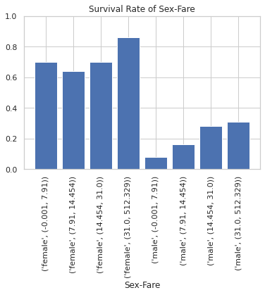

```python
# Sex-Fareごとの生存率計算
F_S_df = train_df.loc[:, ['Survived', 'Sex', 'Fare']]
F_S_df['Fare_bins'] = pd.qcut(F_S_df['Fare'], 4) # Fareは四分位範囲でビンわけ
F_S_cross = pd.crosstab([F_S_df['Sex'],F_S_df['Fare_bins']], F_S_df['Survived'])
F_S_cross['All'] = F_S_cross.sum(axis=1)
F_S_cross['survival_rate'] = F_S_cross[1] / F_S_cross['All']
F_S_cross['survival_rate'] = F_S_cross['survival_rate'].round(2)
print(F_S_cross)


# 可視化
fig =plt.figure()
ax = fig.add_subplot(1,1,1)
index = [str(x).replace('Interval','').replace(", closed='right'", "") for x in F_S_cross.index]
ax.bar(index, F_S_cross['survival_rate'])
ax.set_ylim(0,1)
ax.set_xlabel('Sex-Fare')
ax.set_title('Survival Rate of Sex-Fare')
plt.xticks(rotation=90)
plt.show()
```

4のまとめ

> - 4-1 Pclass-Sex別生存率：「Pclass1&female と Pclass2&female」、「Pclass3&female と Pclass1&male」、「Pclass2&male と Pclass3&male」の３カテゴリで変数化
> - 4-2 Pclass-Age別生存率：「Pclass1&14歳以下 とPclass2&14歳以下」、「Pclass1&15~40歳」、「それ以外」のカテゴリで変数化
> - 4-3 Pclass-Parch別生存率：「Pclass1 & Parch0,1,2 と Pclass2 & Parch1,2,3」、「それ以外」のカテゴリで変数化
> - 4-4 Age-Sex別生存率：「女性 と 男性&4歳以下」、「その他」でカテゴリ分けして変数化
> - 4-5 SibSp-Parch別生存率：「Pclass1&家族連れ と Pclass2&家族連れ」、「Pclass1&一人旅」、「その他」でカテゴリ分けして変数化
> - 4-6 Fare-Age別生存率：変数化せず
> - 4-7 Sex-Fare別生存率：「女性」、「男性&14.454ドル以下」、「男性&14.55ドル以上」の３カテゴリで変数化

## 5.外れ値の処理

- Tukey Methodで、Age, Fare, SibSp, Parchから外れ値除く
- 各レコード毎に２つ以上の外れ値を持つレコードを除く
- Tukey Methodのコード参照サイト： https://gist.github.com/joseph-allen/14d72af86689c99e1e225e5771ce1600

```python
from collections import Counter

def detect_outliers(df, n, features):
    outlier_indices = []

    # iterate over features(columns)
    for col in features:
        # 1st quartile (25%)
        Q1 = np.percentile(df[col], 25)
        # 3rd quartile (75%)
        Q3 = np.percentile(df[col], 75)
        # Interquartile range (IQR)
        IQR = Q3 - Q1

        # outlier step
        outlier_step = 1.5 * IQR

        # Determine a list of indices of outliers for feature col
        outlier_list_col = df[(df[col] < Q1 - outlier_step) | (df[col] > Q3 + outlier_step)].index

        # append the found outlier indices for col to the list of outlier indices
        outlier_indices.extend(outlier_list_col)

    # select observations containing more than 2 outliers
    outlier_indices = Counter(outlier_indices)
    multiple_outliers = list(k for k, v in outlier_indices.items() if v > n)

    return  multiple_outliers

# detect outliers from list of features
# lof = ['example_feature_1', 'example_feature_2']
lof = ['Age', 'Fare', 'SibSp', 'Parch']
# params dataset, number of outliers for rejection, list of features
# Outliers_to_drop = detect_outliers(dataset, 2, lof)
Outliers_to_drop = detect_outliers(train_df, 2, lof)

# chekck outliers_records
train_df.iloc[Outliers_to_drop]
```

|  | PassengerId | Survived | Pclass | Name | Sex | Age | SibSp | Parch | Ticket | Fare | Cabin | Embarked | Cabin_initial |
| --- | --- | --- | --- | --- | --- | --- | --- | --- | --- | --- | --- | --- | --- |
| 27 | 28 | 0 | 1 | Fortune, Mr. Charles Alexander | male | 19.0 | 3 | 2 | 19950 | 263.00 | C23 C25 C27 | S | C |
| 88 | 89 | 1 | 1 | Fortune, Miss. Mabel Helen | female | 23.0 | 3 | 2 | 19950 | 263.00 | C23 C25 C27 | S | C |
| 159 | 160 | 0 | 3 | Sage, Master. Thomas Henry | male | NaN | 8 | 2 | CA. 2343 | 69.55 | NaN | S | X |
| 180 | 181 | 0 | 3 | Sage, Miss. Constance Gladys | female | NaN | 8 | 2 | CA. 2343 | 69.55 | NaN | S | X |
| 201 | 202 | 0 | 3 | Sage, Mr. Frederick | male | NaN | 8 | 2 | CA. 2343 | 69.55 | NaN | S | X |
| 324 | 325 | 0 | 3 | Sage, Mr. George John Jr | male | NaN | 8 | 2 | CA. 2343 | 69.55 | NaN | S | X |
| 341 | 342 | 1 | 1 | Fortune, Miss. Alice Elizabeth | female | 24.0 | 3 | 2 | 19950 | 263.00 | C23 C25 C27 | S | C |
| 792 | 793 | 0 | 3 | Sage, Miss. Stella Anna | female | NaN | 8 | 2 | CA. 2343 | 69.55 | NaN | S | X |
| 846 | 847 | 0 | 3 | Sage, Mr. Douglas Bullen | male | NaN | 8 | 2 | CA. 2343 | 69.55 | NaN | S | X |
| 863 | 864 | 0 | 3 | Sage, Miss. Dorothy Edith "Dolly" | female | NaN | 8 | 2 | CA. 2343 | 69.55 | NaN | S | X |

SibSpとFareとFareの組み合わせで引っかかったのが多い。上記データを除く。

```python
# 外れ値対象データ削除
combined_df = combined_df.drop(Outliers_to_drop, axis=0)
train_df = train_df.drop(Outliers_to_drop, axis=0)

# インデックス振り直し
combined_df.reset_index(drop=True, inplace=True)
train_df.reset_index(drop=True, inplace=True)
```

```python
# combined_dfでのtest_dataの位置確認
combined_df.iloc[875:885,:] # PassengerId=892~

# index:881~ test_data
```

|  | PassengerId | Survived | Pclass | Name | Sex | Age | SibSp | Parch | Ticket | Fare | Cabin | Embarked | Cabin_initial |
| --- | --- | --- | --- | --- | --- | --- | --- | --- | --- | --- | --- | --- | --- |
| 875 | 886 | 0.0 | 3 | Rice, Mrs. William (Margaret Norton) | female | 39.0 | 0 | 5 | 382652 | 29.1250 | NaN | Q | X |
| 876 | 887 | 0.0 | 2 | Montvila, Rev. Juozas | male | 27.0 | 0 | 0 | 211536 | 13.0000 | NaN | S | X |
| 877 | 888 | 1.0 | 1 | Graham, Miss. Margaret Edith | female | 19.0 | 0 | 0 | 112053 | 30.0000 | B42 | S | B |
| 878 | 889 | 0.0 | 3 | Johnston, Miss. Catherine Helen "Carrie" | female | NaN | 1 | 2 | W./C. 6607 | 23.4500 | NaN | S | X |
| 879 | 890 | 1.0 | 1 | Behr, Mr. Karl Howell | male | 26.0 | 0 | 0 | 111369 | 30.0000 | C148 | C | C |
| 880 | 891 | 0.0 | 3 | Dooley, Mr. Patrick | male | 32.0 | 0 | 0 | 370376 | 7.7500 | NaN | Q | X |
| 881 | 892 | NaN | 3 | Kelly, Mr. James | male | 34.5 | 0 | 0 | 330911 | 7.8292 | NaN | Q | X |
| 882 | 893 | NaN | 3 | Wilkes, Mrs. James (Ellen Needs) | female | 47.0 | 1 | 0 | 363272 | 7.0000 | NaN | S | X |
| 883 | 894 | NaN | 2 | Myles, Mr. Thomas Francis | male | 62.0 | 0 | 0 | 240276 | 9.6875 | NaN | Q | X |
| 884 | 895 | NaN | 3 | Wirz, Mr. Albert | male | 27.0 | 0 | 0 | 315154 | 8.6625 | NaN | S | X |

## 6.欠損値の処理

Age,Fare,Embarked,Cabinの欠損値を埋める。

### ・Age

敬称から年齢を推測する

> - Mr., Mister, Mistress, Mr., Mrs.- 大人として14~最高年齢の平均値で埋める
> - Master, Miss - 男の子女の子とみなして0~13歳の子ども達の平均年齢を埋める (Misterが13歳までらしいのでとりあえず13歳で区切る)

```python
# 大人の平均年齢算出
adult_age = round(combined_df[combined_df['Age'] >= 14]['Age'].mean(), 1)
# 子供の平均年齢算出
child_age = round(combined_df[combined_df['Age'] <= 13]['Age'].mean(), 1)

# 欠損値穴埋め
# 大人
combined_df.loc[combined_df['Age'].isnull() & \
                combined_df['Name'].str.findall(r'.*(Mr\.|Mister|Mistress|Mr\.|Mrs\.|Dr\.|Ms\.).*'), 'Age'] = adult_age
# 子供
combined_df.loc[combined_df['Age'].isnull() & \
                combined_df['Name'].str.findall(r'.*(Master|Miss).*'), 'Age'] = child_age
```

```python
combined_df['Age'].isnull().sum()
```

```
0
```

### ・Embarked

```python
# Embarkedが欠損値のデータ確認
combined_df[combined_df['Embarked'].isnull()]
```

|  | PassengerId | Survived | Pclass | Name | Sex | Age | SibSp | Parch | Ticket | Fare | Cabin | Embarked | Cabin_initial |
| --- | --- | --- | --- | --- | --- | --- | --- | --- | --- | --- | --- | --- | --- |
| 60 | 62 | 1.0 | 1 | Icard, Miss. Amelie | female | 38.0 | 0 | 0 | 113572 | 80.0 | B28 | NaN | B |
| 821 | 830 | 1.0 | 1 | Stone, Mrs. George Nelson (Martha Evelyn) | female | 62.0 | 0 | 0 | 113572 | 80.0 | B28 | NaN | B |

3-2-3のFare-Embarkedの箱ひげ図で、80ドルの運賃はEmbarked'C'で75％の範囲に入っているので、'C'で埋める。

```python
combined_df.loc[combined_df['Embarked'].isnull(), 'Embarked'] = 'C'
combined_df['Embarked'].isnull().sum()
```

```
0
```

### ・Fare

```python
# 欠損値データ確認
combined_df[combined_df['Fare'].isnull()]
```

|  | PassengerId | Survived | Pclass | Name | Sex | Age | SibSp | Parch | Ticket | Fare | Cabin | Embarked | Cabin_initial |
| --- | --- | --- | --- | --- | --- | --- | --- | --- | --- | --- | --- | --- | --- |
| 1033 | 1044 | NaN | 3 | Storey, Mr. Thomas | male | 60.5 | 0 | 0 | 3701 | NaN | NaN | S | X |

Pclass3のFareの平均値で埋める

```python
combined_df.loc[combined_df['Fare'].isnull(), 'Fare'] = combined_df.groupby('Pclass')['Fare'].mean()[3]
combined_df['Fare'].isnull().sum()
```

```
0
```

### ・Cabin

- 欠損値は'X'で埋めて、先頭文字を変数として利用する
- 分布を確認するために欠損値を'X'で埋めた変数'Cabin_initial'を作成していたので、処理済み。

## 7.変数の創出

- 7-1 Nameの変数変換（既存変数の変換）
- 7-2 Cabinの変数変換（既存変数の変換）
- 7-3 Ticketの変数変換（既存変数の変換）

上記までのを既存変数としてモデリング

- 7-4 Pclass-Sexから作成 (4-1の結果から新規作成)
- 7-5 Pclass-Ageから作成 (4-2の結果から新規作成)
- 7-6 Pclass-Parchから作成 (4-3の結果から新規作成)
- 7-7 Age-Sexから作成 (4-4の結果から新規作成)
- 7-8 SibSp-Parch-Pclassから作成 (4-5の結果から新規作成)
- 7-9 Sex-Fareから作成 (4-7の結果から新規作成)

既存変数に7-4~7-9の新規変数を加えてモデリング

### 7-1 Nameの変数変換

Nameから敬称取り出して変数化

```python
# 3-1-3で作ったget_title()関数でNameから敬称取り出し
combined_df['title'] = combined_df['Name'].apply(get_title)
combined_df.head()
```

|  | PassengerId | Survived | Pclass | Name | Sex | Age | SibSp | Parch | Ticket | Fare | Cabin | Embarked | Cabin_initial | title |
| --- | --- | --- | --- | --- | --- | --- | --- | --- | --- | --- | --- | --- | --- | --- |
| 0 | 1 | 0.0 | 3 | Braund, Mr. Owen Harris | male | 22.0 | 1 | 0 | A/5 21171 | 7.2500 | NaN | S | X | Mr\. |
| 1 | 2 | 1.0 | 1 | Cumings, Mrs. John Bradley (Florence Briggs Th... | female | 38.0 | 1 | 0 | PC 17599 | 71.2833 | C85 | C | C | Mrs\. |
| 2 | 3 | 1.0 | 3 | Heikkinen, Miss. Laina | female | 26.0 | 0 | 0 | STON/O2. 3101282 | 7.9250 | NaN | S | X | Miss |
| 3 | 4 | 1.0 | 1 | Futrelle, Mrs. Jacques Heath (Lily May Peel) | female | 35.0 | 1 | 0 | 113803 | 53.1000 | C123 | S | C | Mrs\. |
| 4 | 5 | 0.0 | 3 | Allen, Mr. William Henry | male | 35.0 | 0 | 0 | 373450 | 8.0500 | NaN | S | X | Mr\. |

### 7-2 Cabinの変数変換

- 先頭のアルファベットで作成。
- 欠損値は'X'で補完

ー＞分布チェック時に、既に作成済み。変数名：Cabin_initial

### 7-3 Ticketの変数変換

- Ticketから数字部分を取り出し、25000を境界として、0,1の2値変数化。

```python
# 3-1-4で作ったtake_number()でTicketから数値部分取得
combined_df['Ticket_f'] = combined_df['Ticket'].apply(take_number)
# Ticket番号は25000以下なら1、それ以外0
combined_df['Ticket_f'] = combined_df['Ticket_f'].apply(lambda x: 1 if x <=25000 else 0)
```

```python
combined_df.head()
```

|  | PassengerId | Survived | Pclass | Name | Sex | Age | SibSp | Parch | Ticket | Fare | Cabin | Embarked | Cabin_initial | title | Ticket_f |
| --- | --- | --- | --- | --- | --- | --- | --- | --- | --- | --- | --- | --- | --- | --- | --- |
| 0 | 1 | 0.0 | 3 | Braund, Mr. Owen Harris | male | 22.0 | 1 | 0 | A/5 21171 | 7.2500 | NaN | S | X | Mr\. | 1 |
| 1 | 2 | 1.0 | 1 | Cumings, Mrs. John Bradley (Florence Briggs Th... | female | 38.0 | 1 | 0 | PC 17599 | 71.2833 | C85 | C | C | Mrs\. | 1 |
| 2 | 3 | 1.0 | 3 | Heikkinen, Miss. Laina | female | 26.0 | 0 | 0 | STON/O2. 3101282 | 7.9250 | NaN | S | X | Miss | 0 |
| 3 | 4 | 1.0 | 1 | Futrelle, Mrs. Jacques Heath (Lily May Peel) | female | 35.0 | 1 | 0 | 113803 | 53.1000 | C123 | S | C | Mrs\. | 0 |
| 4 | 5 | 0.0 | 3 | Allen, Mr. William Henry | male | 35.0 | 0 | 0 | 373450 | 8.0500 | NaN | S | X | Mr\. | 0 |

### 7-4 Pclass-Sexから変数作成(4-1より)

「Pclass1&female と Pclass2&female」、「Pclass3&female と Pclass1&male」、「Pclass2&male と Pclass3&male」の３カテゴリで変数化

```python
# PclassとSexからラベルを返す関数
def return_label(df):
    if (df['Pclass'] == 1 and df['Sex'] == 'female') or \
                    (df['Pclass'] == 2 and df['Sex'] == 'female'):
        return 2
    elif (df['Pclass'] == 3 and df['Sex'] == 'female') or \
                    (df['Pclass'] == 1 and df['Sex'] == 'male'):
        return 1
    else:
        return 0

# 変数作成
combined_df['Pclass_Sex'] = combined_df.apply(return_label, axis=1)

combined_df[['Pclass', 'Sex', 'Pclass_Sex']].head()
```

|  | Pclass | Sex | Pclass_Sex |
| --- | --- | --- | --- |
| 0 | 3 | male | 0 |
| 1 | 1 | female | 2 |
| 2 | 3 | female | 1 |
| 3 | 1 | female | 2 |
| 4 | 3 | male | 0 |

### 7-5 Pclass-Ageから作成(4-2より)

「Pclass1&14歳以下 とPclass2&14歳以下」、「Pclass1&15~40歳」、「それ以外」のカテゴリで変数化

```python
# PclassとAgeからラベルを返す関数
def return_label(df):
        if (df['Pclass'] == 1 and df['Age'] <= 14) or \
                    (df['Pclass'] == 2 and df['Age'] <= 14):
            return 2
        elif (df['Pclass'] == 1 and df['Age'] >= 15) and \
                    (df['Pclass'] == 1 and df['Age'] <= 40):
            return 1
        else:
            return 0

# 変数作成
combined_df['Pclass_Age'] = combined_df.apply(return_label, axis=1)

combined_df[['Pclass', 'Age', 'Pclass_Age']].head()
```

|  | Pclass | Age | Pclass_Age |
| --- | --- | --- | --- |
| 0 | 3 | 22.0 | 0 |
| 1 | 1 | 38.0 | 1 |
| 2 | 3 | 26.0 | 0 |
| 3 | 1 | 35.0 | 1 |
| 4 | 3 | 35.0 | 0 |

### 7-6 Pclass-Parchから変数作成(4-3より)

「Pclass1 & Parch0,1,2 と Pclass2 & Parch1,2,3」、「それ以外」のカテゴリで変数化

```python
# PclassとParchからラベルを返す関数
def return_label(df):
    if (df['Pclass'] == 1 and df['Parch'] in [0, 1, 2]) or \
                (df['Pclass'] == 2 and df['Parch'] in [1, 2, 3]):
        return 1
    else:
        return 0

# 変数作成
combined_df['Pclass_Parch'] = combined_df.apply(return_label, axis=1)

combined_df[['Pclass', 'Parch', 'Pclass_Parch']].head()
```

|  | Pclass | Parch | Pclass_Parch |
| --- | --- | --- | --- |
| 0 | 3 | 0 | 0 |
| 1 | 1 | 0 | 1 |
| 2 | 3 | 0 | 0 |
| 3 | 1 | 0 | 1 |
| 4 | 3 | 0 | 0 |

### 7-7 Age-Sexから変数作成(4-4)

「女性 と 男性&4歳以下」、「その他」でカテゴリ分けして変数化

```python
# AgeとSexからラベルを返す関数
def return_label(df):
    if df["Sex"] == "female" or (df["Sex"] == 'male' and df["Age"] <= 4):
        return 1
    else:
        return 0

# 変数作成
combined_df['Age_Sex'] = combined_df.apply(return_label, axis=1)

combined_df[['Age', 'Sex', 'Age_Sex']].head()
```

|  | Age | Sex | Age_Sex |
| --- | --- | --- | --- |
| 0 | 22.0 | male | 0 |
| 1 | 38.0 | female | 1 |
| 2 | 26.0 | female | 1 |
| 3 | 35.0 | female | 1 |
| 4 | 35.0 | male | 0 |

### 7-8 SibSp-Parch-Pclassから変数作成(4-5より)

```python
# SibSp、Parch、Pclassからラベルを返す関数
def return_label(df):
    if df['Pclass'] in [1, 2] and df['SibSp'] != 0 and df['Parch'] != 0:
        return 2
    elif df['Pclass'] == 1 and df['SibSp'] == 0 and df['Parch'] == 0:
        return 1
    else:
        return 0

# 変数作成
combined_df['Si_Pa_Pclass'] = combined_df.apply(return_label, axis=1)

combined_df[['Pclass', 'SibSp', 'Parch', 'Si_Pa_Pclass']].head()
```

|  | Pclass | SibSp | Parch | Si_Pa_Pclass |
| --- | --- | --- | --- | --- |
| 0 | 3 | 1 | 0 | 0 |
| 1 | 1 | 1 | 0 | 0 |
| 2 | 3 | 0 | 0 | 0 |
| 3 | 1 | 1 | 0 | 0 |
| 4 | 3 | 0 | 0 | 0 |

### 7-9 Sex-Fareから作成(4-7より)

- 「女性」、「男性&14.454ドル以下」、「男性&14.55ドル以上」の３カテゴリで変数化
- Sex-Pclassの変数とかぶる気がするが、とりあえず作って効果を見る

```python
# SexとFareからラベルを返す関数
def return_label(df):
    if df['Sex'] == 'female':
        return 2
    elif df['Sex'] == 'male' and df['Fare'] > 14.454:
        return 1
    else:
        return 0

# 変数作成
combined_df['Sex_Fare'] = combined_df.apply(return_label,axis=1)

combined_df[['Sex', 'Fare', 'Sex_Fare']].head()
```

|  | Sex | Fare | Sex_Fare |
| --- | --- | --- | --- |
| 0 | male | 7.2500 | 0 |
| 1 | female | 71.2833 | 2 |
| 2 | female | 7.9250 | 2 |
| 3 | female | 53.1000 | 2 |
| 4 | male | 8.0500 | 0 |

## 8. 変数変換

- 8-1 Categorical変数の変換：ラベリングで数値化
- 8-2 標準化：線形回帰モデルも使うので、平均0, 分散1に標準化

### 8-1 Categorical変数の変換

Sex, Embarked, title, Cabin_initial

```python
# カテゴリカル変数のラベリング
# 対象：Sex, Embarked, title, Cabin_initial

# ラベリング用辞書ー生存率の低い順から0,1,2..とラベリング
Sex_dic = {'male': 0, 'female': 1}
Embarked_dic = {'S': 0, 'Q': 1, 'C': 2}
title_dic = {'Mr\.': 0, 'other': 1, 'Master': 2, 'Miss': 3, 'Mrs\.': 4}

# Cabin_initial変換用
def cabin_i(x):
    if x in ['B', 'D', 'E']:
        return 2
    elif x in ['A', 'C', 'F', 'G']:
        return 1
    else:
        return 0

# 変換
labeled_df = combined_df.copy()
labeled_df['Sex'] = labeled_df['Sex'].map(Sex_dic)
labeled_df['Embarked'] = labeled_df['Embarked'].map(Embarked_dic)
labeled_df['title'] = labeled_df['title'].map(title_dic)
labeled_df['Cabin_initial'] = labeled_df['Cabin_initial'].apply(cabin_i)

# 不要な変数削除
labeled_df.drop(columns=['PassengerId', 'Survived', 'Name', 'Ticket', 'Cabin'], inplace=True)

labeled_df.head(4)
```

|  | Pclass | Sex | Age | SibSp | Parch | Fare | Embarked | Cabin_initial | title | Ticket_f | Pclass_Sex | Pclass_Age | Pclass_Parch | Age_Sex | Si_Pa_Pclass | Sex_Fare |
| --- | --- | --- | --- | --- | --- | --- | --- | --- | --- | --- | --- | --- | --- | --- | --- | --- |
| 0 | 3 | 0 | 22.0 | 1 | 0 | 7.2500 | 0 | 0 | 0 | 1 | 0 | 0 | 0 | 0 | 0 | 0 |
| 1 | 1 | 1 | 38.0 | 1 | 0 | 71.2833 | 2 | 1 | 4 | 1 | 2 | 1 | 1 | 1 | 0 | 2 |
| 2 | 3 | 1 | 26.0 | 0 | 0 | 7.9250 | 0 | 0 | 3 | 0 | 1 | 0 | 0 | 1 | 0 | 2 |
| 3 | 1 | 1 | 35.0 | 1 | 0 | 53.1000 | 0 | 1 | 4 | 0 | 2 | 1 | 1 | 1 | 0 | 2 |

### 8-2 標準化（平均0, 分散1）

```python
# 訓練データと提出用テストデータに分ける
Standard_labeled_train = labeled_df.iloc[:881,:]
Standard_labeled_test = labeled_df.iloc[881:, :]
Standard_labeled_test.reset_index(drop=True, inplace=True)
```

```python
# ラベリング後データの標準化
standard_scaler = StandardScaler() #インスタンス
standard_scaler = standard_scaler.fit(Standard_labeled_train.values) # フィッティング

Standard_train_data = standard_scaler.transform(Standard_labeled_train.values) # Normalization
Standard_labeled_train = pd.DataFrame(data=Standard_train_data, columns=labeled_df.columns) # df化

Standard_test_data = standard_scaler.transform(Standard_labeled_test.values) # Normalization
Standard_labeled_test = pd.DataFrame(data=Standard_test_data, columns=labeled_df.columns) # df化
```

```python
Standard_labeled_train.head()
```

|  | Pclass | Sex | Age | SibSp | Parch | Fare | Embarked | Cabin_initial | title | Ticket_f | Pclass_Sex | Pclass_Age | Pclass_Parch | Age_Sex | Si_Pa_Pclass | Sex_Fare |
| --- | --- | --- | --- | --- | --- | --- | --- | --- | --- | --- | --- | --- | --- | --- | --- | --- |
| 0 | 0.829632 | -0.734990 | -0.511305 | 0.625474 | -0.458969 | -0.497646 | -0.593882 | -0.509581 | -0.796109 | 1.295304 | -0.876714 | -0.440559 | -0.650587 | -0.777648 | -0.446914 | -1.135780 |
| 1 | -1.566780 | 1.360563 | 0.632181 | 0.625474 | -0.458969 | 0.837243 | 1.915519 | 0.929332 | 1.673510 | 1.295304 | 1.706514 | 1.657453 | 1.537074 | 1.285929 | -0.446914 | 1.204856 |
| 2 | 0.829632 | 1.360563 | -0.225434 | -0.522532 | -0.458969 | -0.483574 | -0.593882 | -0.509581 | 1.056105 | -0.772020 | 0.414900 | -0.440559 | -0.650587 | 1.285929 | -0.446914 | 1.204856 |
| 3 | -1.566780 | 1.360563 | 0.417777 | 0.625474 | -0.458969 | 0.458180 | -0.593882 | 0.929332 | 1.673510 | -0.772020 | 1.706514 | 1.657453 | 1.537074 | 1.285929 | -0.446914 | 1.204856 |
| 4 | 0.829632 | -0.734990 | 0.417777 | -0.522532 | -0.458969 | -0.480968 | -0.593882 | -0.509581 | -0.796109 | -0.772020 | -0.876714 | -0.440559 | -0.650587 | -0.777648 | -0.446914 | -1.135780 |

・各変数間の相関を確認

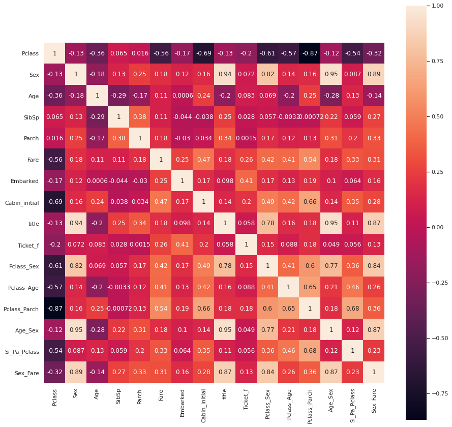

```python
corr = Standard_labeled_train.corr()
fig = plt.figure(figsize=(15, 15))
sns.heatmap(corr, square=True, annot=True)
```

**※ 交互作用的な効果を狙って新しく変数を作成したが、新規で作成した変数が全般的に既存の変数と相関が高いので、逆にノイズとして作用しそうな感じがする・・・。**

## 9. 特徴量選択

- Wrapper Method(Forrward Step Selection)で、一番Accuracyが高い組み合わせを見つける。

```python
# スコア比較用にデータを既存変数、既存+新規変数で分ける

# 既存変数データ
Original_train =  Standard_labeled_train[['Pclass', 'Sex', 'Age','SibSp', 'Parch', 'Fare','Embarked','Cabin_initial', 'title', 'Ticket_f']]
Original_test = Standard_labeled_test[['Pclass', 'Sex', 'Age','SibSp', 'Parch', 'Fare','Embarked','Cabin_initial', 'title', 'Ticket_f']]

# 既存+新規変数データ
Add_train = Standard_labeled_train.copy()
Add_test = Standard_labeled_test.copy()
```

### 9-1 既存の変数からWrapper Methodで特徴量選択

```python
# 全10個の変数から一番Accuracyが高い変数の組み合わせを見つける
sfs = SFS(RandomForestClassifier(n_estimators=100, random_state=0, n_jobs=-1),
          k_features=(1, 10),
          forward=True,
          floating=False,
          verbose=2,
          scoring='accuracy',
          cv=5,
          n_jobs=-1
         ).fit(Original_train, train_df['Survived'])
```

[output not shown]

```python
# 最大スコア
print('score: ', sfs.k_score_)

# 選択された特徴量
print('features: ',sfs.k_feature_names_)
```

```
score:  0.8274460708782743
features:  ('Sex', 'SibSp', 'Parch', 'Embarked', 'Cabin_initial', 'title', 'Ticket_f')
```

既存の変数からの抽出結果

- score: 0.8274460708782743
- features: ('Sex', 'SibSp', 'Parch', 'Embarked', 'Cabin_initial', 'title', 'Ticket_f')

```python
# 対象変数データ抽出
FS_Original_train = Original_train[['Sex', 'SibSp', 'Parch', 'Embarked', 'Cabin_initial', 'title', 'Ticket_f']]
FS_Original_test = Original_test[['Sex', 'SibSp', 'Parch', 'Embarked', 'Cabin_initial', 'title', 'Ticket_f']]
```

### 9-2 既存+新規の変数からWrapper Methodで特徴量選択

```python
# 全16個の変数から一番Accuracyが高い変数の組み合わせを見つける
sfs = SFS(RandomForestClassifier(n_estimators=100, random_state=0, n_jobs=-1),
          k_features=(1, 16),
          forward=True,
          floating=False,
          scoring='accuracy',
          cv=5,
          n_jobs=-1
         ).fit(Add_train, train_df['Survived'])
```

```python
# 最大スコア
print('score: ', sfs.k_score_)

# 選択された特徴量
print('features: ',sfs.k_feature_names_)
```

```
score:  0.8274974319465844
features:  ('Pclass', 'Fare', 'Age_Sex')
```

既存+新規の変数からの抽出結果

- score: 0.8274974319465844
- features: ('Pclass', 'Fare', 'Age_Sex')

```python
# 対象変数データ抽出
FS_Add_train = Add_train[['Pclass', 'Fare', 'Age_Sex']]
FS_Add_test = Add_test[['Pclass', 'Fare', 'Age_Sex']]
```

# (3) モデリングと評価

1. Logistic Regression
2. SVM (rbf kernel)
3. Random Forest
4. Gradient Boosting

```python
# パラメーターチューニング用にデータ分割

# Original_train
Or_x_train, Or_x_test, Or_y_train, Or_y_test = train_test_split(Original_train, train_df['Survived'], test_size=0.25, random_state=1)

# Add_train
Ad_x_train, Ad_x_test, Ad_y_train, Ad_y_test = train_test_split(Add_train, train_df['Survived'], test_size=0.25, random_state=1)

# FS_Original_train
FSO_x_train, FSO_x_test, FSO_y_train, FSO_y_test = train_test_split(FS_Original_train, train_df['Survived'], test_size=0.25, random_state=1)

# FS_Add_train
FSA_x_train, FSA_x_test, FSA_y_train, FSA_y_test = train_test_split(FS_Add_train, train_df['Survived'], test_size=0.25, random_state=1)
```

## 1. Logistic Regression

### ・パラメーターチューニング

```python
%%time

# パラメーター設定
param_grid = {'C': np.logspace(-4, 4, 20),
              'solver': ['liblinear'],
              'random_state': [0]
              }

# grid search で良さげなパラメータ見つける

# Original_train
grid_search = GridSearchCV(LogisticRegression(), param_grid, cv=5, n_jobs=-1)
grid_search.fit(Or_x_train, Or_y_train)
print('---Original_train---')
print('score: ',grid_search.score(Or_x_test, Or_y_test))
print('best parameter: ', grid_search.best_params_)
print('score for train_date: ', grid_search.best_score_, '\n')

# Add_train
grid_search = GridSearchCV(LogisticRegression(), param_grid, cv=5, n_jobs=-1)
grid_search.fit(Ad_x_train, Ad_y_train)
print('---Add_train---')
print('score: ',grid_search.score(Ad_x_test, Ad_y_test))
print('best parameter: ', grid_search.best_params_)
print('score for train_date: ', grid_search.best_score_, '\n')

# FS_Original_train
grid_search = GridSearchCV(LogisticRegression(), param_grid, cv=5, n_jobs=-1)
grid_search.fit(FSO_x_train, FSO_y_train)
print('---FS_Original_train---')
print('score: ',grid_search.score(FSO_x_test, FSO_y_test))
print('best parameter: ', grid_search.best_params_)
print('score for train_date: ', grid_search.best_score_, '\n')

# FS_Add_train
grid_search = GridSearchCV(LogisticRegression(), param_grid, cv=5, n_jobs=-1)
grid_search.fit(FSA_x_train, FSA_y_train)
print('---FS_Add_train---')
print('score: ',grid_search.score(FSA_x_test, FSA_y_test))
print('best parameter: ', grid_search.best_params_)
print('score for train_date: ', grid_search.best_score_, '\n')
```

```
---Original_train---
score:  0.832579185520362
best parameter:  {'C': 1.623776739188721, 'random_state': 0, 'solver': 'liblinear'}
score for train_date:  0.8227272727272729

---Add_train---
score:  0.8371040723981901
best parameter:  {'C': 1.623776739188721, 'random_state': 0, 'solver': 'liblinear'}
score for train_date:  0.8151515151515152

---FS_Original_train---
score:  0.7963800904977375
best parameter:  {'C': 0.23357214690901212, 'random_state': 0, 'solver': 'liblinear'}
score for train_date:  0.8075757575757576

---FS_Add_train---
score:  0.8009049773755657
best parameter:  {'C': 0.23357214690901212, 'random_state': 0, 'solver': 'liblinear'}
score for train_date:  0.793939393939394

CPU times: user 941 ms, sys: 43.7 ms, total: 985 ms
Wall time: 1.29 s
```

補足：

> - Logistic Regressionのパラメーターチューニングを以下のサイトを参照して実施したが、'C'パラメーターが大分細かくなってしまった。こういった細かい値がチューニングに有効か調べる必要あり。

参照サイト： https://towardsdatascience.com/logistic-regression-model-tuning-with-scikit-learn-part-1-425142e01af5

### ・予測と提出

```python
# Original_train -> 0.77990
Or_Lr_model = LogisticRegression(C=1.623776739188721, random_state=0, solver='liblinear')
Or_Lr_model.fit(Original_train.values, np.ravel(train_df['Survived']))
Or_Lr_predicted = Or_Lr_model.predict(Original_test.values)
Or_Lr_df = pd.DataFrame({'PassengerId': test_df['PassengerId'], 'Survived':Or_Lr_predicted})
Or_Lr_df.to_csv('/kaggle/working/Or_Lr_0519.csv', index=False)

# Add_train -> 0.74641
Ad_Lr_model = LogisticRegression(C=1.623776739188721, random_state=0, solver='liblinear')
Ad_Lr_model.fit(Add_train.values, np.ravel(train_df['Survived']))
Ad_Lr_predicted = Ad_Lr_model.predict(Add_test.values)
Ad_Lr_df = pd.DataFrame({'PassengerId': test_df['PassengerId'], 'Survived':Ad_Lr_predicted})
Ad_Lr_df.to_csv('/kaggle/working/Ad_Lr_0519.csv', index=False)

# FS_Original_train -> 0.74641
FS_Or_Lr_model = LogisticRegression(C=0.23357214690901212, random_state=0, solver='liblinear')
FS_Or_Lr_model.fit(FS_Original_train.values, np.ravel(train_df['Survived']))
FS_Or_Lr_predicted = FS_Or_Lr_model.predict(FS_Original_test.values)
FS_Or_Lr_df = pd.DataFrame({'PassengerId': test_df['PassengerId'], 'Survived':FS_Or_Lr_predicted})
FS_Or_Lr_df.to_csv('/kaggle/working/FS_Or_Lr_0519.csv', index=False)

# FS_Add_train -> 0.76555
FS_Ad_Lr_model = LogisticRegression(C=0.23357214690901212, random_state=0, solver='liblinear')
FS_Ad_Lr_model.fit(FS_Add_train.values, np.ravel(train_df['Survived']))
FS_Ad_Lr_pedicted = FS_Ad_Lr_model.predict(FS_Add_test.values)
FS_Ad_Lr_df = pd.DataFrame({'PassengerId': test_df['PassengerId'], 'Survived':FS_Ad_Lr_pedicted})
FS_Ad_Lr_df.to_csv('/kaggle/working/FS_Ad_Lr_0519.csv', index=False)
```

## 2. SVM

### ・パラメーターチューニング

```python
%%time

# パラメータ設定
param_grid = {'kernel': ['rbf'],
              'C' : [0.001, 0.01, 1, 10, 100,1000],
              'gamma':[0.001, 0.01, 1, 10, 100,1000]}


# Original_train
grid_search = GridSearchCV(SVC(), param_grid, cv=5, n_jobs=-1)
grid_search.fit(Or_x_train, Or_y_train)
print('---Original_train---')
print('score: ',grid_search.score(Or_x_test, Or_y_test))
print('best parameter: ', grid_search.best_params_)
print('score for train_date: ', grid_search.best_score_, '\n')

# Add_train
grid_search = GridSearchCV(SVC(), param_grid, cv=5, n_jobs=-1)
grid_search.fit(Ad_x_train, Ad_y_train)
print('---Add_train---')
print('score: ',grid_search.score(Ad_x_test, Ad_y_test))
print('best parameter: ', grid_search.best_params_)
print('score for train_date: ', grid_search.best_score_, '\n')

# FS_Original_train
grid_search = GridSearchCV(SVC(), param_grid, cv=5, n_jobs=-1)
grid_search.fit(FSO_x_train, FSO_y_train)
print('---FS_Original_train---')
print('score: ',grid_search.score(FSO_x_test, FSO_y_test))
print('best parameter: ', grid_search.best_params_)
print('score for train_date: ', grid_search.best_score_, '\n')

# FS_Add_train
grid_search = GridSearchCV(SVC(), param_grid, cv=5, n_jobs=-1)
grid_search.fit(FSA_x_train, FSA_y_train)
print('---FS_Add_train---')
print('score: ',grid_search.score(FSA_x_test, FSA_y_test))
print('best parameter: ', grid_search.best_params_)
print('score for train_date: ', grid_search.best_score_, '\n')
```

```
---Original_train---
score:  0.832579185520362
best parameter:  {'C': 1000, 'gamma': 0.001, 'kernel': 'rbf'}
score for train_date:  0.8303030303030303

---Add_train---
score:  0.8144796380090498
best parameter:  {'C': 1000, 'gamma': 0.001, 'kernel': 'rbf'}
score for train_date:  0.8287878787878787

---FS_Original_train---
score:  0.8099547511312217
best parameter:  {'C': 100, 'gamma': 0.01, 'kernel': 'rbf'}
score for train_date:  0.8303030303030303

---FS_Add_train---
score:  0.8190045248868778
best parameter:  {'C': 10, 'gamma': 1000, 'kernel': 'rbf'}
score for train_date:  0.8227272727272726

CPU times: user 1.69 s, sys: 46.1 ms, total: 1.73 s
Wall time: 8.96 s
```

### ・予測と提出

```python
# Original_train -> 0.78468
Or_SVC_model = SVC(C=1000, gamma=0.001, kernel='rbf')
Or_SVC_model.fit(Original_train.values, np.ravel(train_df['Survived']))
Or_SVC_predicted = Or_SVC_model.predict(Original_test.values)
Or_SVC_df = pd.DataFrame({'PassengerId': test_df['PassengerId'], 'Survived':Or_SVC_predicted})
Or_SVC_df.to_csv('/kaggle/working/Or_SVC_0519.csv', index=False)

# Add_train -> 0.78468
Ad_SVC_model = SVC(C=1000, gamma=0.001, kernel='rbf')
Ad_SVC_model.fit(Add_train.values, np.ravel(train_df['Survived']))
Ad_SVC_predicted = Ad_SVC_model.predict(Add_test.values)
Ad_SVC_df = pd.DataFrame({'PassengerId': test_df['PassengerId'], 'Survived':Ad_SVC_predicted})
Ad_SVC_df.to_csv('/kaggle/working/Ad_SVC_0519.csv', index=False)

# FS_Original_train -> 0.77511
FS_Or_SVC_model = SVC(C=100, gamma=0.01, kernel='rbf')
FS_Or_SVC_model.fit(FS_Original_train.values, np.ravel(train_df['Survived']))
FS_Or_SVC_predicted = FS_Or_SVC_model.predict(FS_Original_test.values)
FS_Or_SVC_df = pd.DataFrame({'PassengerId': test_df['PassengerId'], 'Survived':FS_Or_SVC_predicted})
FS_Or_SVC_df.to_csv('/kaggle/working/FS_Or_SVC_0519.csv', index=False)

# FS_Add_train -> 0.76076
FS_Ad_SVC_model = SVC(C=10, gamma=1000, kernel='rbf')
FS_Ad_SVC_model.fit(FS_Add_train.values, np.ravel(train_df['Survived']))
FS_Ad_SVC_pedicted = FS_Ad_SVC_model.predict(FS_Add_test.values)
FS_Ad_SVC_df = pd.DataFrame({'PassengerId': test_df['PassengerId'], 'Survived':FS_Ad_SVC_pedicted})
FS_Ad_SVC_df.to_csv('/kaggle/working/FS_Ad_SVC_0519.csv', index=False)
```

## 3. Random Forest

### ・パラメーターチューニング

```python
%%time

# パラメータ設定
param_grid = {'n_estimators': [100,200,300,400],
              'max_depth': [50, 100, 150, 200],
              'random_state': [0]}

# Original_train
grid_search = GridSearchCV(RandomForestClassifier(), param_grid, cv=5, n_jobs=-1)
grid_search.fit(Or_x_train, Or_y_train)
print('---Original_train---')
print('score: ',grid_search.score(Or_x_test, Or_y_test))
print('best parameter: ', grid_search.best_params_)
print('score for train_date: ', grid_search.best_score_, '\n')

# Add_train
grid_search = GridSearchCV(RandomForestClassifier(), param_grid, cv=5, n_jobs=-1)
grid_search.fit(Ad_x_train, Ad_y_train)
print('---Add_train---')
print('score: ',grid_search.score(Ad_x_test, Ad_y_test))
print('best parameter: ', grid_search.best_params_)
print('score for train_date: ', grid_search.best_score_, '\n')

# FS_Original_train
grid_search = GridSearchCV(RandomForestClassifier(), param_grid, cv=5, n_jobs=-1)
grid_search.fit(FSO_x_train, FSO_y_train)
print('---FS_Original_train---')
print('score: ',grid_search.score(FSO_x_test, FSO_y_test))
print('best parameter: ', grid_search.best_params_)
print('score for train_date: ', grid_search.best_score_, '\n')

# FS_Add_train
grid_search = GridSearchCV(RandomForestClassifier(), param_grid, cv=5, n_jobs=-1)
grid_search.fit(FSA_x_train, FSA_y_train)
print('---FS_Add_train---')
print('score: ',grid_search.score(FSA_x_test, FSA_y_test))
print('best parameter: ', grid_search.best_params_)
print('score for train_date: ', grid_search.best_score_, '\n')
```

```
---Original_train---
score:  0.8416289592760181
best parameter:  {'max_depth': 50, 'n_estimators': 200, 'random_state': 0}
score for train_date:  0.8106060606060606

---Add_train---
score:  0.8280542986425339
best parameter:  {'max_depth': 50, 'n_estimators': 300, 'random_state': 0}
score for train_date:  0.8196969696969697

---FS_Original_train---
score:  0.8190045248868778
best parameter:  {'max_depth': 50, 'n_estimators': 200, 'random_state': 0}
score for train_date:  0.7878787878787878

---FS_Add_train---
score:  0.832579185520362
best parameter:  {'max_depth': 50, 'n_estimators': 100, 'random_state': 0}
score for train_date:  0.8393939393939395

CPU times: user 4.03 s, sys: 92.3 ms, total: 4.13 s
Wall time: 1min 26s
```

### ・予測と提出

```python
# Original_train -> 0.74641
Or_RF_model = RandomForestClassifier(max_depth=50, n_estimators=200, random_state=0)
Or_RF_model.fit(Original_train.values, np.ravel(train_df['Survived']))
Or_RF_predicted = Or_RF_model.predict(Original_test.values)
Or_RF_df = pd.DataFrame({'PassengerId': test_df['PassengerId'], 'Survived':Or_RF_predicted})
Or_RF_df.to_csv('/kaggle/working/Or_RF_0519.csv', index=False)

# Add_train -> 0.74641
Ad_RF_model = RandomForestClassifier(max_depth=50, n_estimators=300, random_state=0)
Ad_RF_model.fit(Add_train.values, np.ravel(train_df['Survived']))
Ad_RF_predicted = Ad_RF_model.predict(Add_test.values)
Ad_RF_df = pd.DataFrame({'PassengerId': test_df['PassengerId'], 'Survived':Ad_RF_predicted})
Ad_RF_df.to_csv('/kaggle/working/Ad_RF_0519.csv', index=False)

# FS_Original_train -> 0.77033
FS_Or_RF_model = RandomForestClassifier(max_depth=50, n_estimators=200, random_state=0)
FS_Or_RF_model.fit(FS_Original_train.values, np.ravel(train_df['Survived']))
FS_Or_RF_predicted = FS_Or_RF_model.predict(FS_Original_test.values)
FS_Or_RF_df = pd.DataFrame({'PassengerId': test_df['PassengerId'], 'Survived':FS_Or_RF_predicted})
FS_Or_RF_df.to_csv('/kaggle/working/FS_Or_RF_0519.csv', index=False)

# FS_Add_train -> 0.78947
FS_Ad_RF_model = RandomForestClassifier(max_depth=50, n_estimators=100, random_state=0)
FS_Ad_RF_model.fit(FS_Add_train.values, np.ravel(train_df['Survived']))
FS_Ad_RF_pedicted = FS_Ad_RF_model.predict(FS_Add_test.values)
FS_Ad_RF_df = pd.DataFrame({'PassengerId': test_df['PassengerId'], 'Survived':FS_Ad_RF_pedicted})
FS_Ad_RF_df.to_csv('/kaggle/working/FS_Ad_RF_0519.csv', index=False)
```

・特徴量の重要度確認

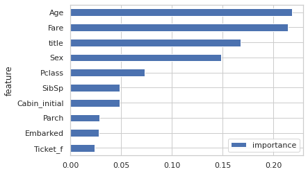

```python
# 既存変数の重要度
fut_df = pd.DataFrame()
fut_df['feature'] = Original_train.columns
fut_df['importance'] = Or_RF_model.feature_importances_
fut_df.sort_values(by='importance', ascending=True, inplace=True)
fut_df.set_index('feature', inplace=True)
fut_df.plot(kind='barh')
```

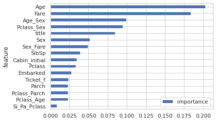

```python
# 新規変数追加版の重要度
fut_df = pd.DataFrame()
fut_df['feature'] = Add_train.columns
fut_df['importance'] = Ad_RF_model.feature_importances_
fut_df.sort_values(by='importance', ascending=True, inplace=True)
fut_df.set_index('feature', inplace=True)
fut_df.plot(kind='barh')
```

## 4. Gradient Boosting

### ・パラメーターチューニング

```python
%%time

# パラメータ設定
param_grid = {'learning_rate': [0.05, 0.1, 0.2],
              'n_estimators': [100, 200, 300, 400],
              'min_samples_split': [x for x in range(2, 21, 4)],
              'max_depth': [2,4,6,8,10]}

# Original_train
grid_search = GridSearchCV(GradientBoostingClassifier(), param_grid, cv=5, n_jobs=-1)
grid_search.fit(Or_x_train, Or_y_train)
print('---Original_train---')
print('score: ',grid_search.score(Or_x_test, Or_y_test))
print('best parameter: ', grid_search.best_params_)
print('score for train_date: ', grid_search.best_score_, '\n')

# Add_train
grid_search = GridSearchCV(GradientBoostingClassifier(), param_grid, cv=5, n_jobs=-1)
grid_search.fit(Ad_x_train, Ad_y_train)
print('---Add_train---')
print('score: ',grid_search.score(Ad_x_test, Ad_y_test))
print('best parameter: ', grid_search.best_params_)
print('score for train_date: ', grid_search.best_score_, '\n')

# FS_Original_train
grid_search = GridSearchCV(GradientBoostingClassifier(), param_grid, cv=5, n_jobs=-1)
grid_search.fit(FSO_x_train, FSO_y_train)
print('---FS_Original_train---')
print('score: ',grid_search.score(FSO_x_test, FSO_y_test))
print('best parameter: ', grid_search.best_params_)
print('score for train_date: ', grid_search.best_score_, '\n')

# FS_Add_train
grid_search = GridSearchCV(GradientBoostingClassifier(), param_grid, cv=5, n_jobs=-1)
grid_search.fit(FSA_x_train, FSA_y_train)
print('---FS_Add_train---')
print('score: ',grid_search.score(FSA_x_test, FSA_y_test))
print('best parameter: ', grid_search.best_params_)
print('score for train_date: ', grid_search.best_score_, '\n')
```

```
---Original_train---
score:  0.8280542986425339
best parameter:  {'learning_rate': 0.2, 'max_depth': 2, 'min_samples_split': 10, 'n_estimators': 200}
score for train_date:  0.8393939393939395

---Add_train---
score:  0.8144796380090498
best parameter:  {'learning_rate': 0.2, 'max_depth': 4, 'min_samples_split': 10, 'n_estimators': 100}
score for train_date:  0.8393939393939395

---FS_Original_train---
score:  0.8099547511312217
best parameter:  {'learning_rate': 0.05, 'max_depth': 2, 'min_samples_split': 6, 'n_estimators': 100}
score for train_date:  0.8318181818181817

---FS_Add_train---
score:  0.8144796380090498
best parameter:  {'learning_rate': 0.2, 'max_depth': 2, 'min_samples_split': 2, 'n_estimators': 200}
score for train_date:  0.8454545454545455

CPU times: user 33.2 s, sys: 1.22 s, total: 34.4 s
Wall time: 20min 24s
```

### ・予測と提出

```python
# Original_train -> 0.75598
Or_GB_model = GradientBoostingClassifier(learning_rate=0.2, max_depth=2, min_samples_split=10, n_estimators=200)
Or_GB_model.fit(Original_train.values, np.ravel(train_df['Survived']))
Or_GB_predicted = Or_GB_model.predict(Original_test.values)
Or_GB_df = pd.DataFrame({'PassengerId': test_df['PassengerId'], 'Survived':Or_GB_predicted})
Or_GB_df.to_csv('/kaggle/working/Or_GB_0519.csv', index=False)

# Add_train -> 0.74641
Ad_GB_model = GradientBoostingClassifier(learning_rate=0.05, max_depth=4, min_samples_split=6, n_estimators=300)
Ad_GB_model.fit(Add_train.values, np.ravel(train_df['Survived']))
Ad_GB_predicted = Ad_GB_model.predict(Add_test.values)
Ad_GB_df = pd.DataFrame({'PassengerId': test_df['PassengerId'], 'Survived':Ad_GB_predicted})
Ad_GB_df.to_csv('/kaggle/working/Ad_GB_0519.csv', index=False)

# FS_Original_train -> 0.77511
FS_Or_GB_model = GradientBoostingClassifier(learning_rate=0.05, max_depth=2, min_samples_split=6, n_estimators=100)
FS_Or_GB_model.fit(FS_Original_train.values, np.ravel(train_df['Survived']))
FS_Or_GB_predicted = FS_Or_GB_model.predict(FS_Original_test.values)
FS_Or_GB_df = pd.DataFrame({'PassengerId': test_df['PassengerId'], 'Survived':FS_Or_GB_predicted})
FS_Or_GB_df.to_csv('/kaggle/working/FS_Or_GB_0519.csv', index=False)

# FS_Add_train -> 0.78468
FS_Ad_GB_model = GradientBoostingClassifier(learning_rate=0.2, max_depth=2, min_samples_split=2, n_estimators=200)
FS_Ad_GB_model.fit(FS_Add_train.values, np.ravel(train_df['Survived']))
FS_Ad_GB_pedicted = FS_Ad_GB_model.predict(FS_Add_test.values)
FS_Ad_GB_df = pd.DataFrame({'PassengerId': test_df['PassengerId'], 'Survived':FS_Ad_GB_pedicted})
FS_Ad_GB_df.to_csv('/kaggle/working/FS_Ad_GB_0519.csv', index=False)
```